# 0_Processing_updated

Lolita Muller & Namita Joshi (Mainly Lolita <3 )

2025-10-02

# Preparation

To run this code, download the file “AdaptationElements” available at: https://doi.org/10.7910/DVN/VK3CP9. Adjust the file path below with the correct location where you would saved the “AdaptationElements” file

# Step 1: Hazard type

This section classifies climate-related hazards mentioned in the `ElementText` column of the `adaptdata` dataset using regex-based keyword matching, aligned with the protocol’s definitions.

1. **Column Creation**  
   A new column `HazardType` is added to store the hazard category for each entry. This column is positioned after `ElementText`.
2. **Keyword Mapping**  
   Hazard categories are mapped to regex patterns that represent keywords found in the protocol definitions. These keywords are matched case-insensitively within the `ElementText`.
3. **Tagging**  
   The script loops over all hazard patterns and tags any matching rows accordingly.

### Hazard Categories and Associated Keywords

| Hazard Category | Keywords Used |
| --- | --- |
| Extreme temperature | heat wave, heatwave, excessive heat, high temperature, extreme temperature, extreme heat, extremely low, cold waves, cold wave, snow, ice, frost, freeze, severe winter, maximum and minimum, warmer, hi… |
| Storm | storm, tropical storm, cyclone, cyclones, Cyclonic activity, typhoon, typhoons, hail, lightning, thunderstorm, heavy rain, windstorm, sand storm, dust storm, tornado, violent rains, torrential, strong… |
| Drought | drought, drought cycle, prolonged droughts, drougths, dry spell, dry days, aridity |
| Wildfire | wildfire, wild fire, forest fire, land fire, bush fire, pasture fire, fire |
| Landslide | landslide, land slide |
| Flood | flood, coastal flood, riverine flood, flash flood, ice jam flood, inundation |
| Change in temperature | change in temperature, alteration in average temperature, temperature change, temperature rise, temperature drop, consistent change in temperature, rise in temperature, increase in temperature, increa… |
| Change in precipitation | change in precipitation, alteration in precipitation, precipitation patterns, shift in timing, shift in amount, shift in intensity, shift in frequency, rainfall, precipitation, distribution of rains, … |
| Salinization | salinization, salt content, saltwater, salt water, salinity, increase in salt content |
| Land degradation | land degradation, decline in land quality, decline in land health, pasture degradation, desertification, loss of organic matter, degradation of land, erosion, soil erosion |
| Sea level rise | sea level rise, sea level, increase in sea level, coastal flooding, coastal erosion, beach loss, coastline retreat, submersion, water mass |
| Sea temperature | sea temperature, sea surface temperature, change in sea temperature, ocean temperature, water temperature, surface temperature, seawater surface |
| Ocean acidification | ocean acidification, reduction in pH, acidity, acidification, acidic, coral |
| Pest and disease | pest, disease, epidemic, infestation, invasion, insect infestation, vector-borne, biological event, invasive species |

## Coverage of hazard type

```
## Hazard rows assigned a category: 1478 out of 1781
```

```
## **Coverage Rate:** 83 %
```

## Hazard type summary data

| Hazard Category | Occurrences |
| --- | --- |
| Extreme temperature | 458 |
| Change in precipitation | 446 |
| Flood | 293 |
| Drought | 265 |
| Storm | 251 |
| Change in temperature | 240 |
| Sea level rise | 134 |
| Wildfire | 90 |
| Pest and disease | 65 |
| Landslide | 55 |

[output cut: 4 more lines]

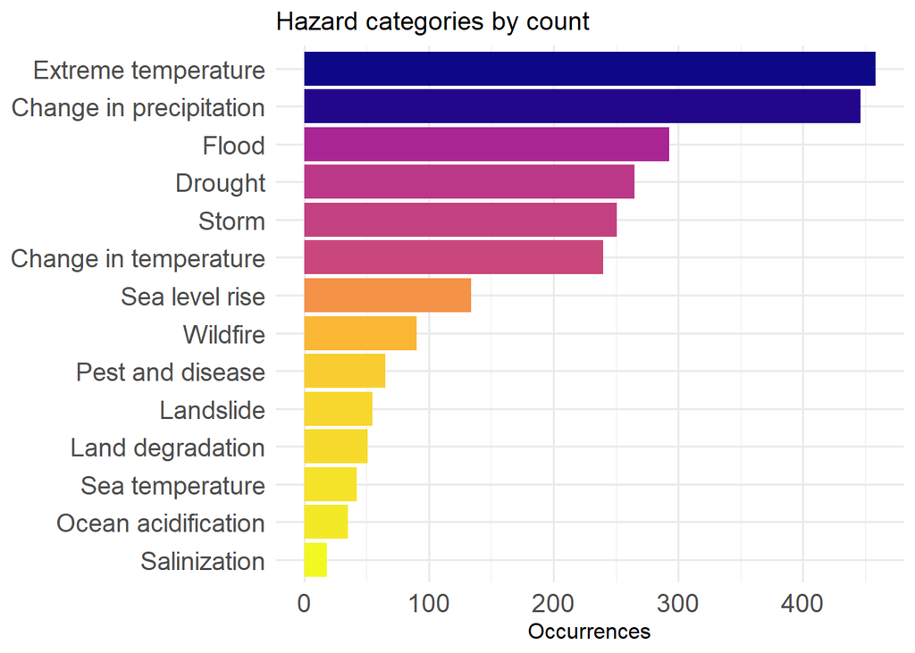

## Hazard type raw data

|  | Country | Document | ElementText | HazardType |
| --- | --- | --- | --- | --- |
| 1 | Algeria | BTR | <span title='An average increase of +0.63°C in the North compared to the annual norm. The years 2020 to 2023 stand out clearly from the lot of the said decade, with a record increase of +1.25°C record… |  |
| 2 | Algeria | BTR | An intense heat wave affected northern Algeria bet... | Extreme temperature |
| 3 | Algeria | BTR | <span title='For the North region, the cumulative rainfall, during the period 2020-2023, reveals contrasting values in 2021, with precipitation close to normal in some localities. However, a notable d… | Change in precipitation |
| 4 | Algeria | BTR | <span title='For the Southern region of Algeria, it experienced significant variability in rainfall during the period 2020-2023. While 2021 presented a near-normal cumulative rainfall, or even excess … | Change in precipitation |
| 5 | Algeria | BTR | <span title='Minimum and maximum temperatures will experience a significant increase. The summer months will show the greatest increases, with maximum temperature increases reaching up to 5.72°C in Au… | Change in temperature |
| 6 | Algeria | BTR | <span title='By 2041-2060. Precipitation tends to decrease gradually throughout the century, especially during the summer months (July, August). However, a slight increase is observed during the autum… | Change in precipitation |
| 7 | Algeria | BTR | By 2081-2100, projections indicate a relative decr... | Change in precipitation |
| 8 | Algeria | BTR | <span title='Forest fires are classified as a major risk and remain the main cause of the degradation of the national forest heritage, with rates of 2,800 fires recorded on average over the last ten y… | Wildfire |
| 9 | Algeria | BTR | <span title='The effects of climate change are manifested by shorter rainy seasons, intense heat waves, an increase in flooding, a drastic reduction in water supply to watersheds, significant drawdown… | Extreme temperature;Flood;Change in precipitation;Salinization |
| 10 | Algeria | BTR | <span title='Droughts have had a proven impact on the surface water potential of the North of the country with a downward trend: 6.5 billion m3 /year at the end of the 1970s, 5 billion m3 /year in the… | Drought |

[output cut: 1771 more lines]

# Step 2: Systems at risk

We assign a SystemType to each row of adaptdata where the element is “System at risk”. This classification is based on the official reporting protocol definitions, which describe different climate-sensitive systems affected by hazards (e.g., agriculture, biodiversity, infrastructure).

To do this, we use a dictionary of keyword patterns that match text found in the ElementText column. These keywords are derived from the protocol and expanded where needed to capture variations in language.

Only rows where the element is “System at risk” are considered.

The following table summarizes the system categories used for classification and the corresponding keyword patterns:

| System Type | Keywords Used |
| --- | --- |
| Crop | crop, cropping systems, crop production, yield, cultivated area, agriculture, agricultural, agricultural production, agricultural pests, pest, irrigated, rain-fed, farming, land use planning, crop los… |
| Livestock | livestock, pasture, pastoralist, pastoral area, grazing, animal health, productivity losses, herder, livestock loss |
| Fisheries and aquaculture | fish, fisheries, aquaculture, fishing, marine harvest |
| Forest | forest, forestry, forest product, tree, non-timber |
| Terrestrial | terrestrial ecosystem, terrestrial, drylands, land resource, natural resource, ecosystem structure, ecosystem services, ecological system, desertification, land degradation, soil degradation, soil ero… |
| Freshwater | freshwater, wetlands, inland wetlands, water resource, drinking water, potable water, water quality, water availability, water supply, river, water scarcity, water shortage, hydrological cycle, water … |
| Biodiversity | biodiversity, flora, fauna, species, species extinction, extinction, range of species, ecosystem change |
| Coastal | coast, coastal, marine, mangrove, ocean, coral, beach, coastal erosion, sea level rise, blue carbon, coastal ecosystem, coastal zone |
| Food and nutrition | food security, food insecure, food insecurity, nutrition, malnutrition, hunger, food safety, food availability, famine, undernutrition, overnutrition, obesity |
| Gender and inclusion | gender, women, youth, children, elderly, inclusion, social exclusion, vulnerable group, vulnerable population, minority group, indigenous, small-scale producer, pastoralist, fishing communities, fores… |
| Livelihoods and poverty | livelihood, poverty, income, employment, labor, economic activity, loss of income, loss of livelihood, safety net, insurance, socio-economic development, tourism, subsistence, workforce, economic, tou… |
| Health | health, mental health, morbidity, mortality, vector-borne disease, water-borne disease, infectious disease, respiratory disease, malaria, epidemic, climate-sensitive disease, heat morbidity, disease, … |
| Infrastructure and services | infrastructure, critical infrastructure, services, critical services, road, bridge, electricity, power supply, energy, water supply, sanitation, hygiene, education, school, building, housing, settleme… |
| Human security and Peace | migration, displacement, conflict, armed conflict, national security, human security, organized conflict, climate-induced migration, refugee, peace |

## Coverage of system at risk type

```
## **System at Risk Coverage:** 1428 of 1605 rows were successfully assigned a category.
```

```
## **Coverage Rate:** 89 %
```

## System at risk type summary data

| System at Risk Category | Occurrences |
| --- | --- |
| Infrastructure and services | 545 |
| Crop | 363 |
| Freshwater | 322 |
| Health | 297 |
| Coastal | 280 |
| Livelihoods and poverty | 238 |
| Biodiversity | 189 |
| Forest | 136 |
| Terrestrial | 128 |
| Fisheries and aquaculture | 70 |

[output cut: 4 more lines]

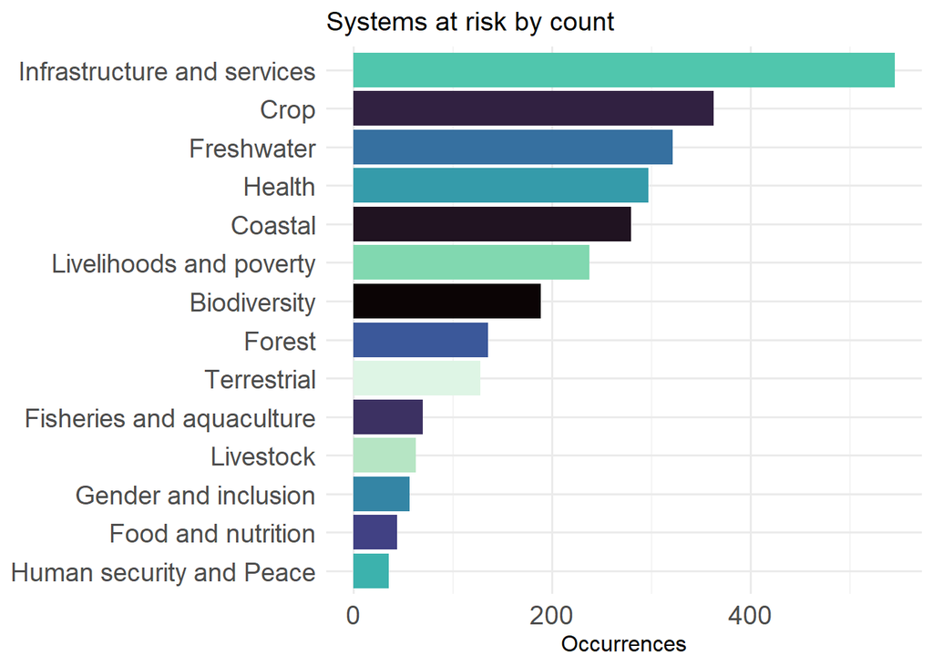

by regions

| Region | System at Risk Category | Occurrences |
| --- | --- | --- |
| Latin America and the Carribean | Infrastructure and services | 137 |
| Western Europe and Other states | Infrastructure and services | 128 |
| Latin America and the Carribean | Crop | 104 |
| Eastern Europe | Infrastructure and services | 98 |
| Asia-Pacific | Infrastructure and services | 97 |
| Latin America and the Carribean | Coastal | 93 |
| Africa | Infrastructure and services | 85 |
| Latin America and the Carribean | Health | 84 |
| Asia-Pacific | Crop | 83 |
| Latin America and the Carribean | Livelihoods and poverty | 83 |

[output cut: 60 more lines]

## System at risk type raw data

|  | ...1 | Country | Document | Element | ElementLabel | ElementText | HazardType | SystemType | Sector | ResultType | Action level | ActionType | IndicatorType_theme | IndicatorType_information | IndicatorType_function | BarrierType |
| --- | --- | --- | --- | --- | --- | --- | --- | --- | --- | --- | --- | --- | --- | --- | --- | --- |
| 1 |  | Algeria | BTR | System at risk | Impacts and vulnerabilities | <span title='The increase in the frequency and intensity of RMC due to the occurrence and spread of diseases and epidemics that affect women more, as care often falls to them. In addition, this increa… |  | Gender and inclusion;Health;Infrastructure and services | Gender |  |  |  |  |  |  |  |
| 2 |  | Algeria | BTR | System at risk | Impacts and vulnerabilities | <span title='The scarcity of food has a direct impact on food security and affects women more, who deprive themselves of food for the benefit of their family, resulting in deficiencies during pregnanc… |  | Food and nutrition;Gender and inclusion | Gender |  |  |  |  |  |  |  |
| 3 |  | Algeria | BTR | System at risk | Impacts and vulnerabilities | The adaptation of pathogens to climate change repr... |  | Crop;Livestock | Animal and plant health |  |  |  |  |  |  |  |
| 4 |  | Algeria | BTR | System at risk | Impacts and vulnerabilities | <span title='Warming is expected to lead to an expansion of the geographical area, an increase in winter survival, an increase in the number of generations, and finally an increase in the risk of tran… |  | Health | Animal and plant health |  |  |  |  |  |  |  |
| 5 |  | Algeria | BTR | System at risk | Impacts and vulnerabilities | <span title='Forest fires are classified as a major risk and remain the main cause of the degradation of the national forest heritage, with rates of 2,800 fires recorded on average over the last ten y… |  | Forest | Forestry |  |  |  |  |  |  |  |
| 6 |  | Algeria | BTR | System at risk | Impacts and vulnerabilities | <span title='The effects of climate change are manifested by shorter rainy seasons, intense heat waves, an increase in flooding, a drastic reduction in water supply to watersheds, significant drawdown… |  | Freshwater;Coastal;Health;Infrastructure and services | Water resources |  |  |  |  |  |  |  |
| 7 |  | Algeria | BTR | System at risk | Impacts and vulnerabilities | <span title='The evolution of the water reserves of dams over the past two decades unequivocally confirms the alternation between dry and wet periods. These cycles, which were previously balanced and … |  | Freshwater | Water resources |  |  |  |  |  |  |  |
| 8 |  | Algeria | BTR | System at risk | Impacts and vulnerabilities | The regulated volumes, for which the dams were des... |  | Freshwater | Water resources |  |  |  |  |  |  |  |
| 9 |  | Algeria | BTR | System at risk | Impacts and vulnerabilities | <span title='The phenomenon of exceptional floods, outside the rainy season, is increasingly frequent in certain watersheds, with real risks to the safety of property and people downstream, as well as… |  | Terrestrial | Water resources |  |  |  |  |  |  |  |
| 10 |  | Algeria | BTR | System at risk | Impacts and vulnerabilities | There are also more frequent outbreaks of epidemic... |  | Health | Health |  |  |  |  |  |  |  |

[output cut: 1418 more lines]

# Step 3: Sectors

We classify sectors in two ways:

1. **SectorType (IPCC categories)** — based on keywords found in the `Sector` and `SystemType` columns. This follows the sector taxonomy defined in the MPGs (Table 1).
2. **SectorType_GGA (GGA themes)** — which maps the sectors into broader Global Goal on Adaptation (GGA) thematic groups as per the protocol.

The tagging logic first applies regular expressions to the text in `Sector`, with some fallback rules based on the `SystemType` when relevant. The classification is additive and accounts for overlapping sector concepts.

Below is a summary table of sector categories and the associated keywords used.

### SectorType (IPCC categories) - Keywords used

| IPCC Sector Category | Keywords / Match Terms |
| --- | --- |
| Food, fiber and other ecosystem products | agri, agro, agriculture, food, crop, livestock, animal, fish, fisheries, aquacultur, aquaculture, seed, irrigation, value chain, land use, land tenure, land and forestry, agroforest, Agriculture and f… |
| Terrestrial and freshwater ecosystems | forest, environ, environment, enviornment, ecosystem, biodiversity, natural, ecology, ecolog, wildlife, REDD, peatland, protected area, Terrestrial, Freshwater, land |
| Ocean and coastal ecosystems | ocean, marine, coast, coastal, coastal land use, coastal zone, blue carbon, mangrove, Tourism and Coastal Zone Management, Coastal zone management |
| Water, sanitation and hygiene | sanitation, water and sanitation, sewerage, hygiene, water use, water security, water and energy, water, sanitation and waste |
| Cities, settlements and key infrastructure | city, cities, urban, settlement, infrastructure, housing, habitat, industr, waste, transport, energy, landfills, sanitary landfills, mining, mineral resources, mineral products, telecommunications, In… |
| Health, wellbeing and communities | health, well-being, wellbeing, nutrition, culture, territorial communit, territorial communities, local knowledge, Human security, Vulnerable communities, Territorial development |
| Livelihoods, poverty and sustainable development | social, poverty, people, econom, capacity, education, employment, tourism, rural development, sustainable development, economic and social infrastructure, Livelihoods and poverty, protection, social p… |
| Crosscutting | cross-cutting, cross cutting, cross-sectoral, innovation, research, R&D, integration, empower, gender, women, youth, disaster, risk, climate, climate service, meteo, warning, governance, legislation, … |
| Not specified | Not specified |

## Sector GGA

| GGA Sector Theme | Keywords / Match Terms |
| --- | --- |
| Water and sanitation | sanitation, water and sanitation, sewerage, hygiene, water security, water use, water and energy, water, sanitation and waste |
| Food and agriculture | agri, agro, agriculture, food, crop, livestock, animal, fish, fisheries, aquacultur, aquaculture, seed, irrigation, value chain, land use, land tenure, land and forestry, agroforest, nutrition, food s… |
| Health | health, well-being, wellbeing, territorial communit, territorial communities, local knowledge, Human security, Vulnerable communities, Territorial development |
| Biodiversity and ecosystems | ocean, marine, coast, coastal land use, coastal zone, blue carbon, mangrove, forest, environ, environment, enviornment, ecosystem, biodiversity, natural, ecology, ecolog, wildlife, REDD, peatland, pro… |
| Infrastructure and human settlements | city, cities, urban, settlement, infrastructure, housing, habitat, industr, waste, transport, energy, landfills, sanitary landfills, mining, mineral resources, mineral products, telecommunications, In… |
| Poverty eradication and livelihoods | social, poverty, people, econom, capacity, education, employment, tourism, rural development, sustainable development, economic and social infrastructure, livelihood, income, revenue, social protectio… |
| Cultural heritage | cultur, cultural heritage, heritage site, traditional knowledge, local knowledge, indigenous |

## sector for all rows

```r
# Ensure column exists
if (!"SectorType_GGA" %in% names(adaptdata)) adaptdata$SectorType_GGA <- NA_character_

adaptdata <- adaptdata %>%
  mutate(
    # Use Sector if available; if not, fall back to ElementText
    .gga_text = if_else(
      !is.na(Sector) & str_trim(Sector) != "",
      paste0(as.character(Sector), " ", coalesce(as.character(ElementText), "")),
      coalesce(as.character(ElementText), "")
    )
  ) %>%
  rowwise() %>%
  mutate(
    .counts_gga = list(vapply(gga_patterns, function(pat) {
      str_count(.gga_text, regex(pat, ignore_case = TRUE))
    }, integer(1))),
    SectorType_GGA = {
      # Special case: Sector exactly "water"
      if (!is.na(Sector) && str_to_lower(str_trim(Sector)) == "water") {
        "Water and sanitation"
      } else {
        cnt <- unlist(.counts_gga)
        if (all(cnt == 0L)) NA_character_ else {
          winners <- which(cnt == max(cnt))
          gga_priority[winners[1]]
        }
      }
    }
  ) %>%
  ungroup() %>%
  select(-.gga_text, -.counts_gga)
```

## Sector coverage

```
## **SectorType (IPCC):** 6851 of 7295 rows tagged
```

[output not shown]

```
## **Coverage Rate:** 93.9 %
```

```r
# adaptdata_previous<-read.csv("adaptdata_results_nano6.csv")
#
# adaptdata <- adaptdata_previous %>%
#   select(-SectorType_GGA) %>%                # drop old classification
#   left_join(
#     adaptdata %>% select(...1, SectorType_GGA),
#     by = "...1"                             # replace with the correct unique key
#   )
#
# write.csv(adaptdata,"data/adaptdata_results_nano6.csv")
# # Option 2: If you ran the improved regex classification *directly* on adaptdata
# # then just overwrite:
# adaptdata <- adaptdata %>%
#   mutate(SectorType_GGA = adaptdata_new$SectorType_GGA)
```

## Sector type summary

| IPCC Sector Category | Occurrences |
| --- | --- |
| Food, fiber and other ecosystem products | 2044 |
| Terrestrial and freshwater ecosystems | 1731 |
| Cities, settlements and key infrastructure | 1159 |
| Health, wellbeing and communities | 811 |
| Livelihoods, poverty and sustainable development | 385 |
| Ocean and coastal ecosystems | 323 |
| Crosscutting | 307 |
| Water, sanitation and hygiene | 91 |

| GGA Sector Category | Occurrences |
| --- | --- |
| Food and agriculture | 2019 |
| Biodiversity and ecosystems | 1934 |
| Infrastructure and human settlements | 1161 |
| Health | 836 |
| Poverty eradication and livelihoods | 547 |
| Water and sanitation | 109 |
| Cultural heritage | 22 |

[figure not shown]

## Sector type raw data

|  | X.2 | X.1 | ...1 | X | ...3 | RowID | Country | Document | Element | ElementLabel | ElementText | HazardType | SystemType | Sector | SectorType | ResultType | Action.level | ActionType | IndicatorType_theme | IndicatorType_information | IndicatorType_function | BarrierType | SectorType_GGA | ClimateImpact_Keywords | ImpactCategories | From_SystemAtRisk | Source_ElementLabel | InterventionType_GPT | ActionType_GPT | … |
| --- | --- | --- | --- | --- | --- | --- | --- | --- | --- | --- | --- | --- | --- | --- | --- | --- | --- | --- | --- | --- | --- | --- | --- | --- | --- | --- | --- | --- | --- | --- |
| 1 | 4 | 4 | 4 | 4 | 4 | 4 | Rwanda | BTR | System at risk | Heavy precipitation | The mountain and Lake Kivu climate zones face recurring issues related to flooding and soil erosion, necessitating infrastructure improvements to manage the impacts of heavy precipitation. |  | Terrestrial;Infrastructure and services |  | Terrestrial and freshwater ecosystems |  |  |  |  |  |  |  | Biodiversity and ecosystems |  |  |  |  |  |  | … |
| 2 | 7 | 7 | 7 | 7 | 7 | 7 | Rwanda | BTR | System at risk | Heavy precipitation | The Southern Province is highlighted as the most vulnerable, with districts like Huye, Gisagara, and Ruhango being particularly at risk. These areas are heavily reliant on agriculture, making them sus… |  | Crop;Food and nutrition |  | Food, fiber and other ecosystem products |  |  |  |  |  |  |  | Food and agriculture |  |  |  |  |  |  | … |
| 3 | 9 | 9 | 9 | 9 | 9 | 9 | Rwanda | BTR | System at risk | Heavy precipitation | In rapidly expanding urban areas, growing concerns center around water shortages during prolonged dry spells and the heightened risk of flooding and landslides, particularly in vulnerable informal set… |  | Freshwater;Infrastructure and services |  | Terrestrial and freshwater ecosystems |  |  |  |  |  |  |  | Biodiversity and ecosystems |  |  |  |  |  |  | … |
| 4 | 14 | 13 | 13 | 13 | 13 | 13 | Rwanda | BTR | System at risk | Heavy precipitation | Peaks in rainfall are observed around 1998 and 2002, while significant drops occur in 2016 and 2021. These fluctuations may be linked to climatic events such as El Niño and La Niña, which influence pr… |  | Crop;Freshwater;Infrastructure and services |  | Food, fiber and other ecosystem products |  |  |  |  |  |  |  | Food and agriculture |  |  |  |  |  |  | … |
| 5 | 23 | 21 | 21 | 21 | 21 | 21 | Rwanda | BTR | System at risk | Temperature increase | For agriculture, warmer nights and fewer cool periods can alter crop cycles and reduce yields, while higher temperatures drive increased water and energy demands. |  | Crop;Infrastructure and services |  | Food, fiber and other ecosystem products |  |  |  |  |  |  |  | Food and agriculture |  |  |  |  |  |  | … |
| 6 | 24 | 22 | 22 | 22 | 22 | 22 | Rwanda | BTR | Climate impact | Temperature increase | Rising temperatures also influence human health, exacerbating heat-related illnesses, and disrupt ecosystems, which may lead to shifts in species distribution and ecosystem functions. |  |  | Health | Health, wellbeing and communities |  |  |  |  |  |  |  | Health |  | Human health burden |  |  |  |  | … |
| 7 | 29 | 26 | 26 | 26 | 26 | 26 | Rwanda | BTR | System at risk | Temperature increase | Projected higher temperatures can drive increased water and energy demands, as well as exacerbate heat-related illnesses and disrupt ecosystems, potentially leading to shifts in species distribution a… |  | Biodiversity;Infrastructure and services |  | Terrestrial and freshwater ecosystems |  |  |  |  |  |  |  | Biodiversity and ecosystems |  |  |  |  |  |  | … |
| 8 | 32 | 28 | 28 | 28 | 28 | 28 | Rwanda | BTR | System at risk | Temperature increase | Positive developments in Rwanda are at risk from rising temperatures and fluctuating rainfall. These climate challenges could significantly affect key sectors such as agriculture, energy, health, and … |  | Crop;Livelihoods and poverty;Health;Infrastructure and services |  | Food, fiber and other ecosystem products |  |  |  |  |  |  |  | Poverty eradication and livelihoods |  |  |  |  |  |  | … |
| 9 | 33 | 29 | 29 | 29 | 29 | 29 | Rwanda | BTR | Climate impact | Temperature increase | The majority of agricultural households still rely on rainfed cultivation, and the sector is hindered by variable rainfall, poor infrastructure, substantial postharvest losses, and lack of access to i… |  |  | Agriculture | Food, fiber and other ecosystem products |  |  |  |  |  |  |  | Food and agriculture |  | Crop production loss |  |  |  |  | … |
| 10 | 34 | 30 | 30 | 30 | 30 | 30 | Rwanda | BTR | Hazard | Temperature increase | Rising temperatures compromise the quality and productivity of highly lucrative, temperature-sensitive tea and coffee (which account for more than 20 per cent of export earnings) as agroecological zon… | Change in temperature |  | Agriculture | Food, fiber and other ecosystem products |  |  |  |  |  |  |  | Food and agriculture |  |  |  |  |  |  | … |

[output cut: 6887 more lines]

## Sector consistency analysis

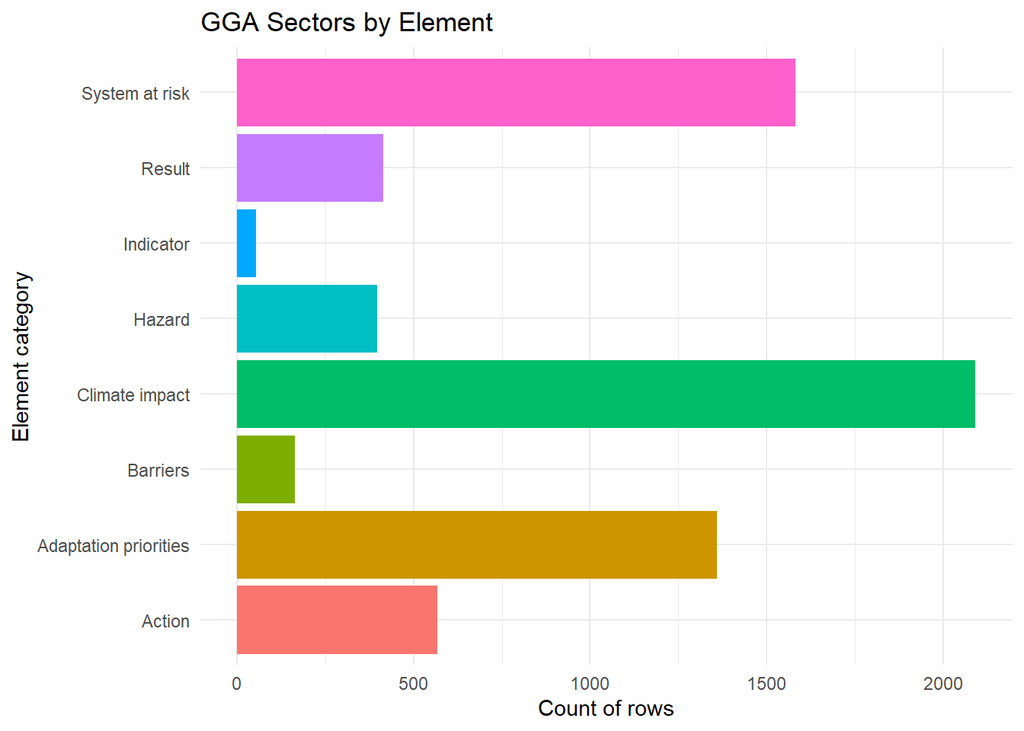

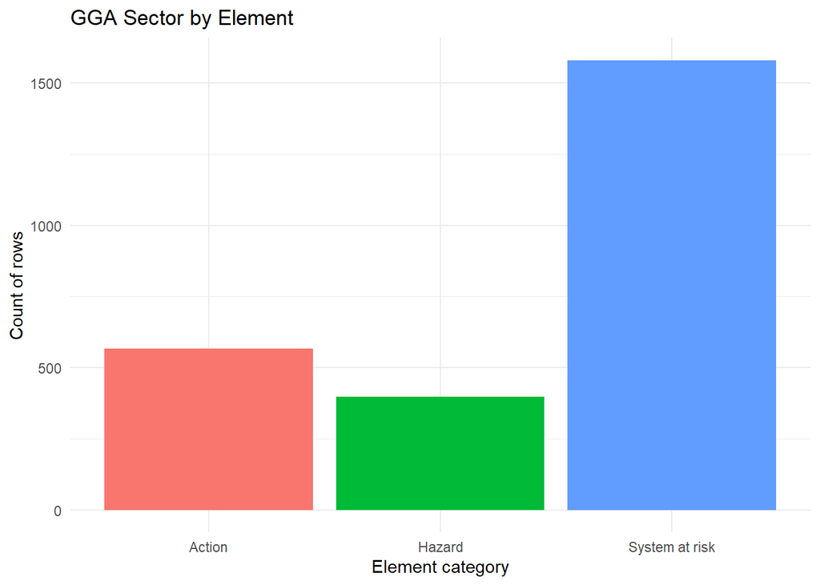

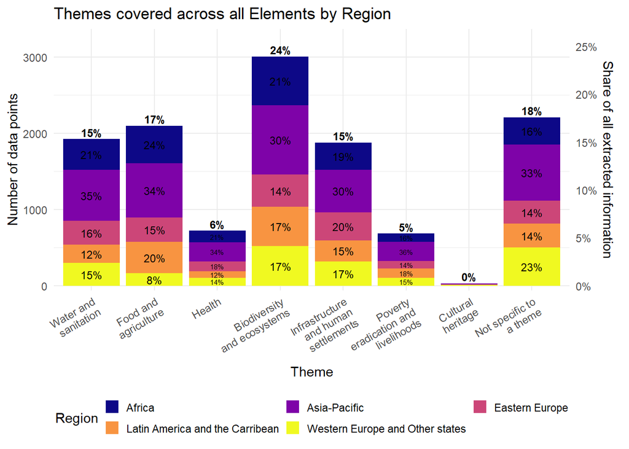

## Sector consistency per country

```r
# Elements of interest
elements_focus <- c("Hazard", "System at risk", "Action")

# Count rows per Country, Element, and SectorType_GGA
theme_counts_country <- adaptdata %>%
  filter(Element %in% elements_focus,
         !is.na(SectorType_GGA),
         SectorType_GGA != "",
         SectorType_GGA != "NA") %>%
  group_by(Country, Element, SectorType_GGA) %>%
  summarise(n = n(), .groups = "drop") %>%
  arrange(Country, Element, desc(n))

# Interactive table
datatable(theme_counts_country,
          options = list(pageLength = 15, autoWidth = TRUE),
          rownames = FALSE)
```

| Country | Element | SectorType_GGA | n |
| --- | --- | --- | --- |
| Algeria | Action | Biodiversity and ecosystems | 5 |
| Algeria | Action | Food and agriculture | 5 |
| Algeria | Action | Water and sanitation | 5 |
| Algeria | Hazard | Water and sanitation | 2 |
| Algeria | Hazard | Biodiversity and ecosystems | 1 |
| Algeria | System at risk | Water and sanitation | 10 |
| Algeria | System at risk | Biodiversity and ecosystems | 3 |
| Algeria | System at risk | Food and agriculture | 3 |
| Andorra | Action | Biodiversity and ecosystems | 1 |
| Andorra | Action | Food and agriculture | 1 |

[output cut: 900 more lines]

```r
theme_counts_country_all <- adaptdata %>%
  filter(!is.na(SectorType_GGA),
         SectorType_GGA != "",
         SectorType_GGA != "NA") %>%
  group_by(Country, Element, SectorType_GGA) %>%
  summarise(n = n(), .groups = "drop") %>%
  arrange(Country, Element, desc(n))

# Interactive table
datatable(theme_counts_country_all,
          options = list(pageLength = 15, autoWidth = TRUE),
          rownames = FALSE)
```

| Country | Element | SectorType_GGA | n |
| --- | --- | --- | --- |
| Algeria | Action | Biodiversity and ecosystems | 5 |
| Algeria | Action | Food and agriculture | 5 |
| Algeria | Action | Water and sanitation | 5 |
| Algeria | Adaptation priorities | Food and agriculture | 18 |
| Algeria | Adaptation priorities | Biodiversity and ecosystems | 12 |
| Algeria | Adaptation priorities | Water and sanitation | 11 |
| Algeria | Adaptation priorities | Infrastructure and human settlements | 3 |
| Algeria | Barriers | Infrastructure and human settlements | 2 |
| Algeria | Barriers | Poverty eradication and livelihoods | 1 |
| Algeria | Climate impact | Water and sanitation | 16 |

[output cut: 2005 more lines]

# Step 4 : Climate Impact

## 4.1 GPT Extraction — impact keywords

- Each *Climate impact* passage is reduced by GPT to **short exact phrases** of consequences  
  (e.g., *“water scarcity”; “crop yield loss”; “heat-related illness”*).
- Hazards (*“storm”*) and actions (*“irrigation”*) are excluded unless phrased as impacts  
  (e.g., *“increased flooding”*).

## 4.2 Categorization — from phrases to classes

- Phrases are mapped to a fixed set of **impact categories**
  - Water availability shortfall
  - Water quality deterioration
  - Crop production loss
  - Livestock impacts
  - Soil degradation
  - Fisheries & aquaculture decline
  - Food security & nutrition decline
  - Human health burden
  - Mental health impacts
  - Healthcare system strain
  - Mortality & injury
  - Displacement & migration
  - Damage to buildings & infrastructure
  - Energy system impacts
  - Transport disruption
  - Supply chain & logistics disruptions
  - Economic & livelihood losses
  - Tourism & recreation impacts
  - Ecosystem degradation & biodiversity loss
  - Soil erosion & land degradation
  - Marine ecosystem stressors
  - Cultural heritage impacts
  - Service delivery disruptions
  - Carbon storage & productivity decline
  - Coastal inundation & shoreline erosion
  - Cryosphere degradation & ground instability
  - Air quality deterioration
  - Agricultural pests & diseases
  - Agricultural system shifts
  - Potential gains
- Each category has sample keywords + regex rules to ensure consistent matches.
- Rows with only hazards (no consequences) are dropped.
- Multiple categories can apply; results stored in `ImpactCategories`.

## 4.3 include the relevant system at risk rows

## 4.4 Climate impact summary data

# load manual data after check

| Impact Category | Occurrences |
| --- | --- |
| Human mortality &amp; morbidity | 475 |
| Water availability &amp; quality | 447 |
| Ecosystem degradation &amp; biodiversity loss | 345 |
| Economic &amp; livelihood losses | 254 |
| Energy system impacts | 186 |
| Coastal inundation &amp; shoreline erosion | 169 |
| Crop production loss | 163 |
| Transport disruption | 148 |
| Agricultural pests &amp; diseases | 102 |
| Damage to buildings &amp; infrastructure | 76 |

[output cut: 18 more lines]

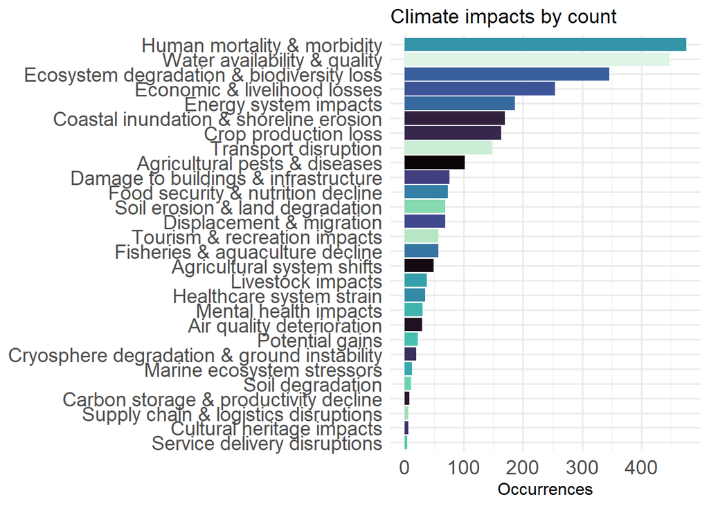

by regions

| Region | Impact Category | Occurrences |
| --- | --- | --- |
| Asia-Pacific | Human mortality &amp; morbidity | 153 |
| Africa | Water availability &amp; quality | 137 |
| Africa | Human mortality &amp; morbidity | 118 |
| Asia-Pacific | Water availability &amp; quality | 118 |
| Africa | Ecosystem Degradation &amp; Biodiversity Loss | 92 |
| Asia-Pacific | Economic &amp; Livelihood Losses | 91 |
| Asia-Pacific | Ecosystem Degradation &amp; Biodiversity Loss | 85 |
| Latin America and the Carribean | Human mortality &amp; morbidity | 84 |
| Eastern Europe | Human mortality &amp; morbidity | 68 |
| Latin America and the Carribean | Ecosystem Degradation &amp; Biodiversity Loss | 66 |

[output cut: 65 more lines]

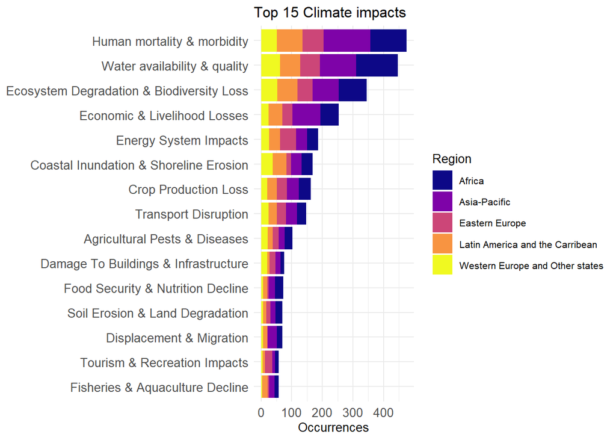

[figure not shown]

# Step 4.5 : Raw data

This show 10 random rows for each climate impact categories. The raw text is included as well as the keywords that justifiy the category.

|  | Impact Category | Element Text | Extracted Keywords | All Selected Categories |
| --- | --- | --- | --- | --- |
| 1 | Agricultural pests & diseases | <span title='Due to increased frequency of forest fires and occurrence of strong winds icing events that cause damage, floods, pest attacks and similar, higher damage to forest ecosystems are expected… | forest fires; pest attacks; loss of forest functions; reduction in value of wood varieties | Crop production loss; Agricultural pests & diseases |
| 2 | Agricultural pests & diseases | Reduction of energy consumption in hot period; | Increase in pests | Agricultural pests & diseases |
| 3 | Agricultural pests & diseases | <span title='Rising temperatures are also expected to accelerate the drying of major water bodies like Lake Balkhash, located in southeastern Kazakhstan. The lake basin supports about one-fifth of the… | resurgence of pests; attacked the few remaining crops; severely impacted by the drought | Agricultural pests & diseases |
| 4 | Agricultural pests & diseases | Increased spread of pests, diseases, and weeds due to climate changes affecting their growth and interactions. | Increased spread of pests, diseases, and weeds | Agricultural pests & diseases |
| 5 | Agricultural pests & diseases | <span title='As temperatures rise and precipitation patterns shift, the range and intensity of agricultural pests and diseases are likely to expand. This will require the development of integrated pes… | water scarcity; increased pest and disease pressure; food security; Subsistence farmers; increased rural poverty; migration | Agricultural pests & diseases; Agricultural system shifts |
| 6 | Agricultural pests & diseases | <span title='Marine submersion and saline intrusions along low-lying coasts are linked to the invasion of water marine inland. They invade low-lying areas, mainly maritime marshes and are caused by th… |  | Agricultural pests & diseases |
| 7 | Agricultural pests & diseases | Climate change is increasing the risks of forest fires, ecosystem degradation, and a decline in forests’ capacity to sequester carbon. | resurgence of pests; attacked the few remaining crops; severely impacted by the drought | Agricultural pests & diseases |
| 8 | Agricultural pests & diseases | Pest/disease stress | Pest/disease stress | Agricultural pests & diseases |
| 9 | Agricultural pests & diseases | Higher temperatures can also result in poorer crop quality and increased pest and disease pressur | poorer crop quality; increased pest and disease pressure | Agricultural pests & diseases |
| 10 | Agricultural pests & diseases | Emergence of new pests and resistance of the existing, such as weevil, key and slugs. |  | Agricultural pests & diseases |

[output cut: 288 more lines]

# Step 5 : Action level and type

## 5.1 Action type

**Goal.** Tag each *Action* with a single **type** to describe the primary adaptation approach.

# Action Type & Intervention Categories

This dataset classifies climate adaptation measures into broad **intervention categories**.  
Each intervention contains **types**, which group related actions, and each type includes specific **actions** (and sometimes subactions).

## Intervention Categories

### *Ecosystem based*

Focus on maintaining and restoring natural systems.  
Includes intervention types such as:  
- **Biodiversity development** – actions to enhance biodiversity (e.g., ecological buffer zones, pollination support).  
- **Ecological restoration** – restoring degraded ecosystems (e.g., afforestation, climate-resilient trees).  
- **Green infrastructure** – using vegetation and permeable systems for adaptation (e.g., rain gardens, green roofs).  
- **Agroforestry** – integrating trees into agricultural systems.  
- **Animals** – livestock and aquaculture resilience.  
- **Crop diversification** – multiple crops to reduce risk.  
- **Energy** – biogas, improved cookstoves, etc.  
- **Migration** – relocating crops/livestock in response to climate.  
- **Nutrient management** – compost, manure, fertility practices.  
- **Pest and disease management** – integrated pest management, biological control.  
- **Postharvest** – storage, drying, reducing food loss.  
- **Schedule modification** – shifting planting/harvest calendars.  
- **Soil management** – mulching, conservation tillage, improved fallows.  
- **Water management** – irrigation efficiency, water harvesting.

### *Institutional*

Policies, governance, and frameworks enabling adaptation.  
Includes:  
- **Economic (policy level)** – finance and incentives from institutions (grants, subsidies, PES).  
- **Government policies and programs** – national/local adaptation plans, sectoral programs.  
- **Laws and regulations** – binding rules such as zoning, building codes, protected areas.  
- **Research development** – climate modeling, monitoring, R&D, policy analysis.

### *Social*

Adaptation driven by people, communities, and knowledge.  
Includes:  
- **Behavioural** – household/community practices (diet change, water storage, advocacy).  
- **Educational** – awareness, training, gender & inclusion, extension services.  
- **Informational** – climate/market/health information, early warning systems.  
- **Economic (household level)** – income diversification, livelihood strategies.

### *Infrastructure / Structural / Physical*

Hard measures, services, and technology.  
Includes:  
- **Engineered and built environment** – seawalls, dams, drainage, resilient transport.  
- **Services** – service delivery platforms like social protection, healthcare.  
- **Supply-chain improvement** – logistics, storage, market access.  
- **Technological** – precision agriculture, IoT, improved breeds/varieties, renewable energy.

**Method**

| Action Type | Occurrences |
| --- | --- |
| government policies and programs | 494 |
| informational | 252 |
| water management | 180 |
| research development | 116 |
| economic | 114 |
| educational | 97 |
| laws and regulations | 70 |
| ecological restoration | 67 |
| biodiversity development | 60 |
| engineered and built environment | 50 |

[output cut: 14 more lines]

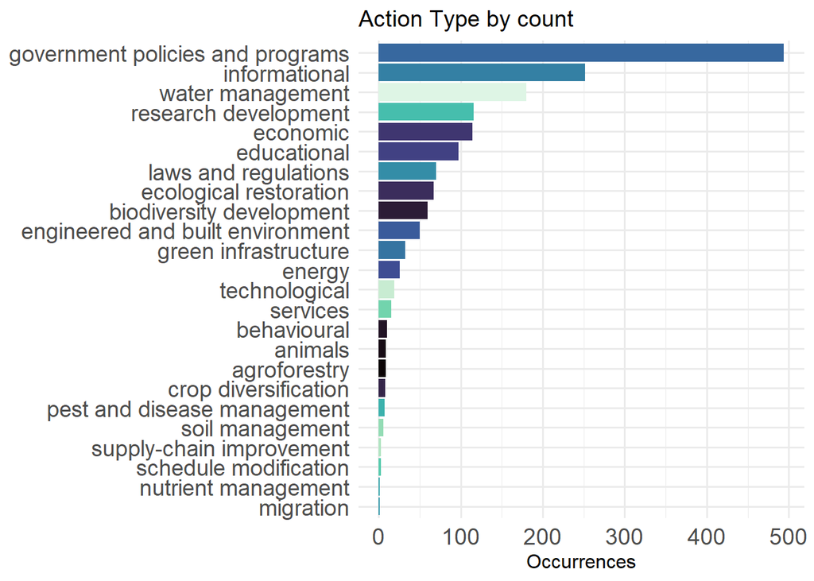

| Region | Action Type | Occurrences |
| --- | --- | --- |
| Asia-Pacific | government policies and programs | 237 |
| Western Europe and Other states | government policies and programs | 143 |
| Asia-Pacific | informational | 109 |
| Western Europe and Other states | informational | 90 |
| Asia-Pacific | water management | 82 |
| Africa | government policies and programs | 81 |
| Asia-Pacific | educational | 53 |
| Asia-Pacific | economic | 50 |
| Western Europe and Other states | water management | 49 |
| Asia-Pacific | research development | 45 |

[output cut: 85 more lines]

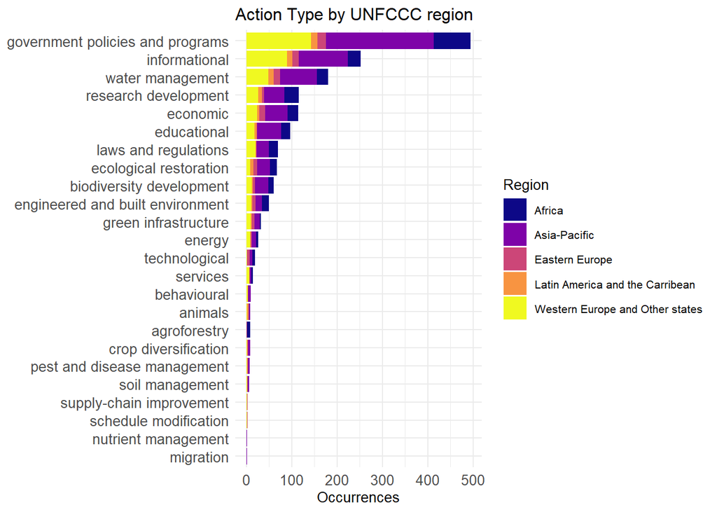

| Action Type | Occurrences |
| --- | --- |
| institutional | 794 |
| ecosystem based | 409 |
| social | 359 |
| infrastructure/structural / physical | 87 |

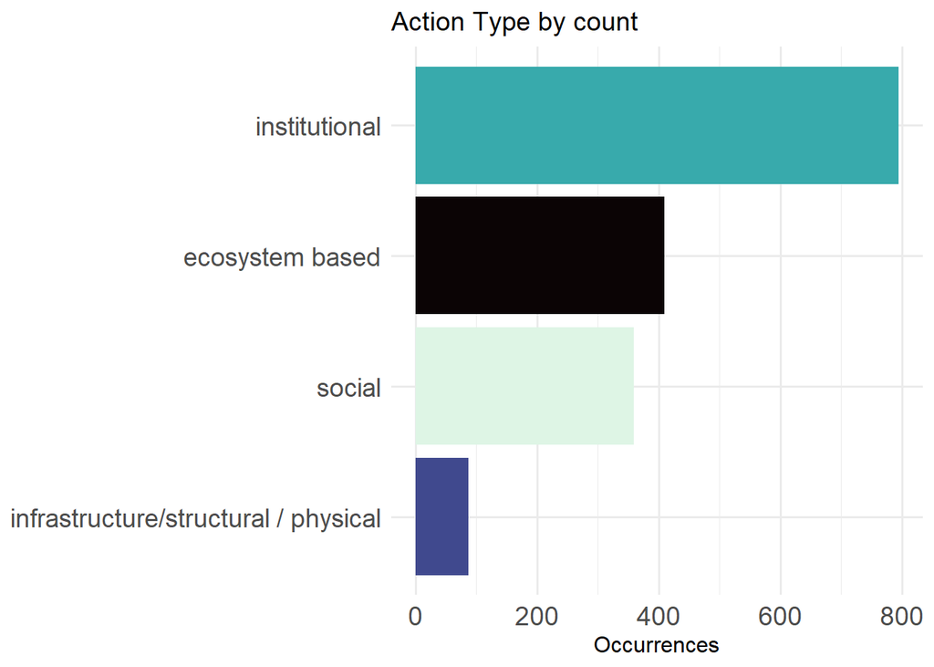

by regions

| Region | Action Type | Occurrences |
| --- | --- | --- |
| Asia-Pacific | institutional | 359 |
| Western Europe and Other states | institutional | 213 |
| Asia-Pacific | ecosystem based | 178 |
| Asia-Pacific | social | 168 |
| Africa | institutional | 156 |
| Western Europe and Other states | social | 111 |
| Western Europe and Other states | ecosystem based | 98 |
| Africa | ecosystem based | 64 |
| Africa | social | 48 |
| Eastern Europe | institutional | 39 |

[output cut: 10 more lines]

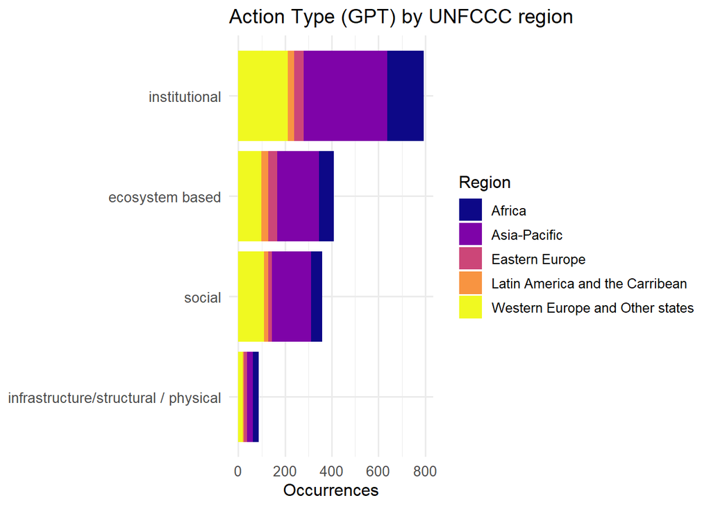

## Action type data

|  | Action Type | Country | Document | ElementText | InterventionType_GPT |
| --- | --- | --- | --- | --- | --- |
| 1 | ecosystem based | Kenya | BTR | <span title='The Kenya Water Towers Agency, which is concerned with conservation, rehabilitation, and sustainable management of water towers, has initiated a number of adaptation initiatives mostly ai… | agroforestry |
| 2 | ecosystem based | Greece | BTR | The River Basin Management Plans (RBMPs) have contributed to the NAS implementation through measures to safeguard water resources and incr... | water management |
| 3 | ecosystem based | Türkiye | BTR | <span title='In terms of water management, the project develops climate change projections and vulnerability assessments at the NUTS-1 level, addressing the growing concern of water scarcity in Türkiy… | water management |
| 4 | ecosystem based | Netherlands | BTR | <span title='Regional and local governments play crucial roles in implementing tailored adaptation strategies. Provinces develop regional plans aligning with national policies, while municipalities in… | water management |
| 5 | ecosystem based | Algeria | BTR | Optimization and rehabilitation of irrigation systems | water management |
| 6 | ecosystem based | Denmark | BTR | <span title='Denmark presented the DK2020 network, where all 98 municipalities receive technical support and share knowledge in their development of climate actions plans that live up to the Climate A… | water management |
| 7 | ecosystem based | Azerbaijan | BTR | <span title='In 2019, farmers are receiving new irrigation methods, small grants and training in the Shaki region. UNDP predicts that after receiving these resources, farmers can efficiently harvest m… | water management |
| 8 | ecosystem based | Azerbaijan | BTR | <span title='Technical support will be provided for 2025 NDC updates, regulatory framework improvement, capacity building, MRV systems, mainstreaming climate change into policies, local adaptation pro… | water management |
| 9 | ecosystem based | China | BTR | <span title='first batch of 19 pilot cities for regional water recycling have been selected, and 78 cities carried out pilot projects for regional utilization of recycled water. We also created 409 of… | water management |
| 10 | ecosystem based | Australia | BTR | <span title='Supporting Resilient and Regenerative Agriculture: Regional Climate Partnerships have delivered a number of initiatives to support farmers to manage climate risks. This includes resilient… | soil management |

[output cut: 30 more lines]

## 5.2 Action level

Action Level classification

**Goal.** Distinguish whether each *Action* reported is **preparatory groundwork** or a **substantive adaptation measure**.

**Definitions**

- **Groundwork** — upstream or enabling work such as:
  - impact/vulnerability assessments, scenarios, conceptual tools
  - policy recommendations, planning frameworks
- **Substantive action** — concrete measures such as:
  - organizational development, regulations, awareness/outreach, education/training
  - monitoring/MEL, infrastructure, technology/innovation
  - financial mechanisms, resource transfer, funding

**Method**

- GPT reads each *Action* text and must return **exactly one label**: *Groundwork* or *Substantive action*.
- If no clear match, the model returns `NA`.
- The result is stored in `ActionLevel_GPT` and previewed in a datatable.

| Action Level | Occurrences |
| --- | --- |
| Substantive action | 1072 |
| Groundwork | 544 |

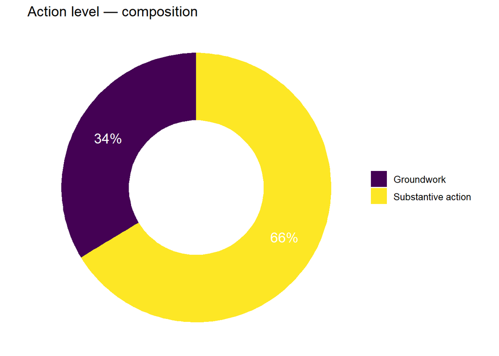

by regions

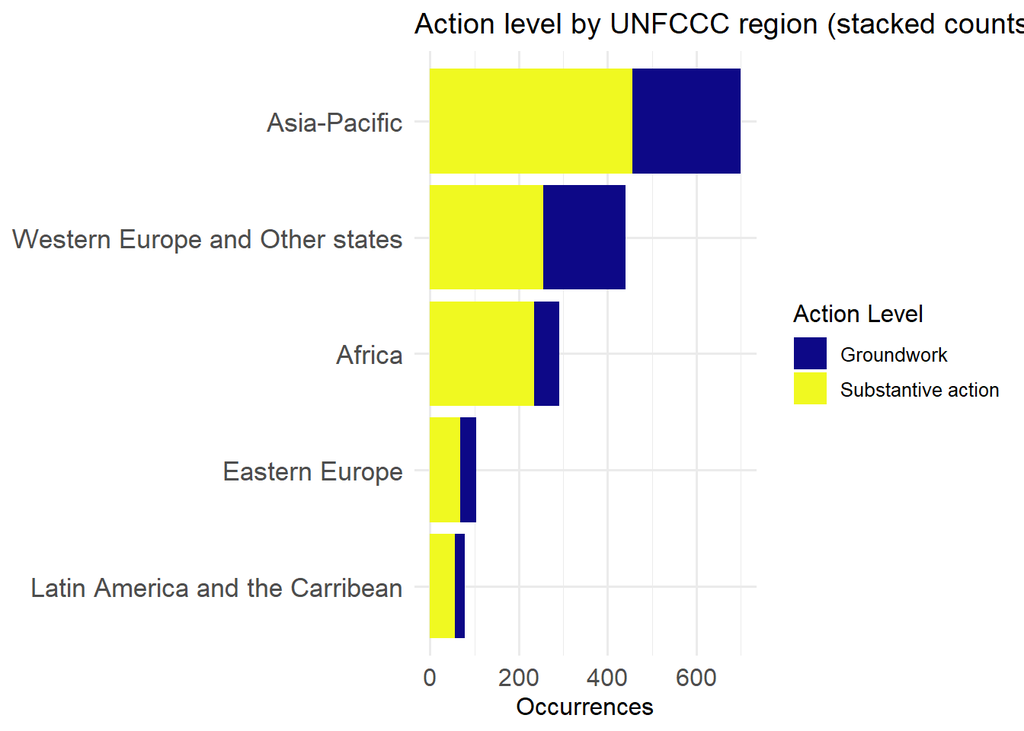

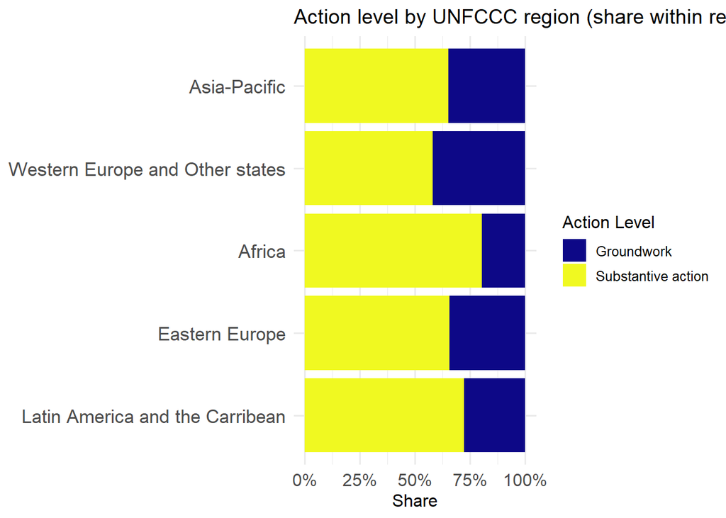

|  | Country | Document | ElementText | ActionLevel_GPT |
| --- | --- | --- | --- | --- |
| 1 | Rwanda | BTR | Investments in climate-resilient agriculture and sustainable practices | Substantive action |
| 2 | Rwanda | BTR | <span title='Incorporation of climate adaptation and resilience in the National Strategy for Transformation (NST2, 2024–2029), the updated Green Growth and Climate Resilience Strategy (GGCRS, first ad… | Groundwork |
| 3 | Rwanda | BTR | <span title='In 2023, GIZ in partnership with MoE initiated a new template ‘’ Rwanda NDC Finance Flow’ to track the information on financial flows for mitigation and adaptation initiative in Rwanda. T… | Groundwork |
| 4 | Rwanda | BTR | <span title='Rwanda has made a deliberate and strategic effort to integrate gender considerations into its climate change adaptation and environmental management actions. This commitment is reflected … | Groundwork |
| 5 | Rwanda | BTR | Rwanda has supported key women’s organizations in building their capacity to mainstream gender in these areas | Substantive action |
| 6 | Rwanda | BTR | Promoting women’s access to climate-resilient livelihoods, clean energy solutions, and capacity-building programs tailored to enhance their ... | Substantive action |
| 7 | Bulgaria | BTR | Promoting water efficient practices in agriculture | Substantive action |
| 8 | Bulgaria | BTR | Upgrading energy infrastructure to withstand extreme weather | Substantive action |
| 9 | Bulgaria | BTR | Bulgaria has also advanced public awareness initiatives and leveraged European Union funding to support adaptation projects, particularly in... | Substantive action |
| 10 | Bulgaria | BTR | <span title='Restoration of wetlands along the Danube River, including the Persina Nature Park and Kalimok-Brushlen Protected Site, where over 4,000 hectares of former marshlands have been reconnected… | Substantive action |

[output cut: 1639 more lines]

# Step 6 : Results

**Method**  
- GPT reads the *Result* text and returns **exactly one label** from the list above (or `NA` if unclear).  
- We **store the model’s reply verbatim** in `ResultType_GPT` (no normalization here); any cleanup or remapping happens later.

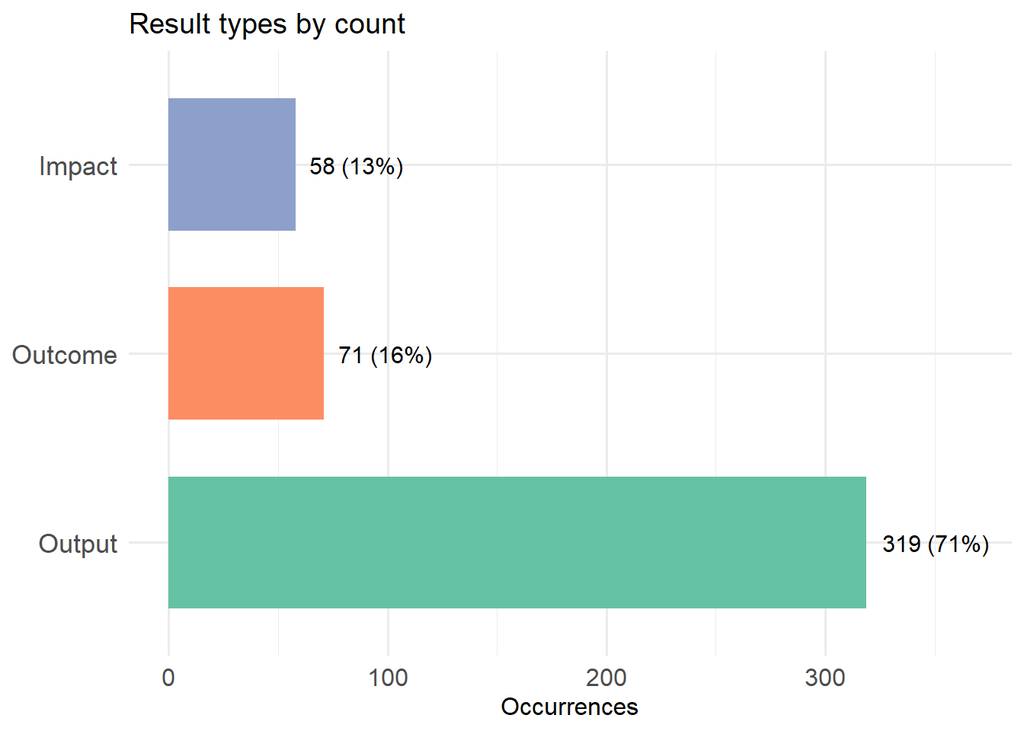

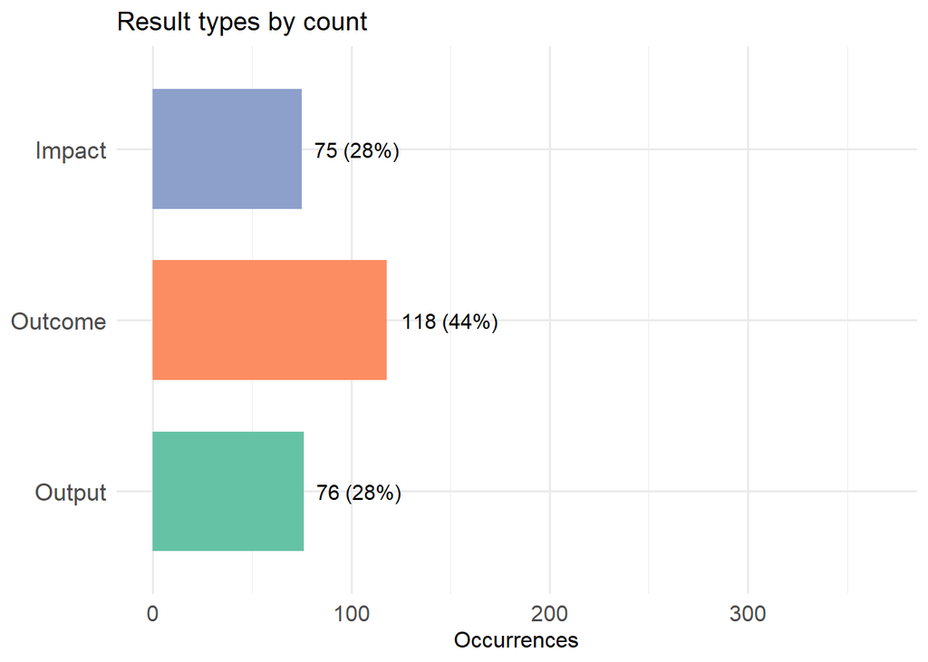

by regions

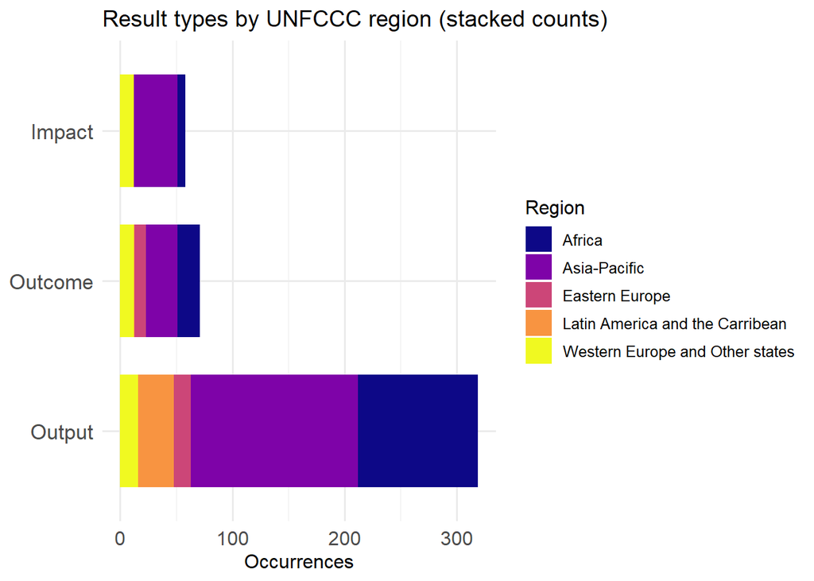

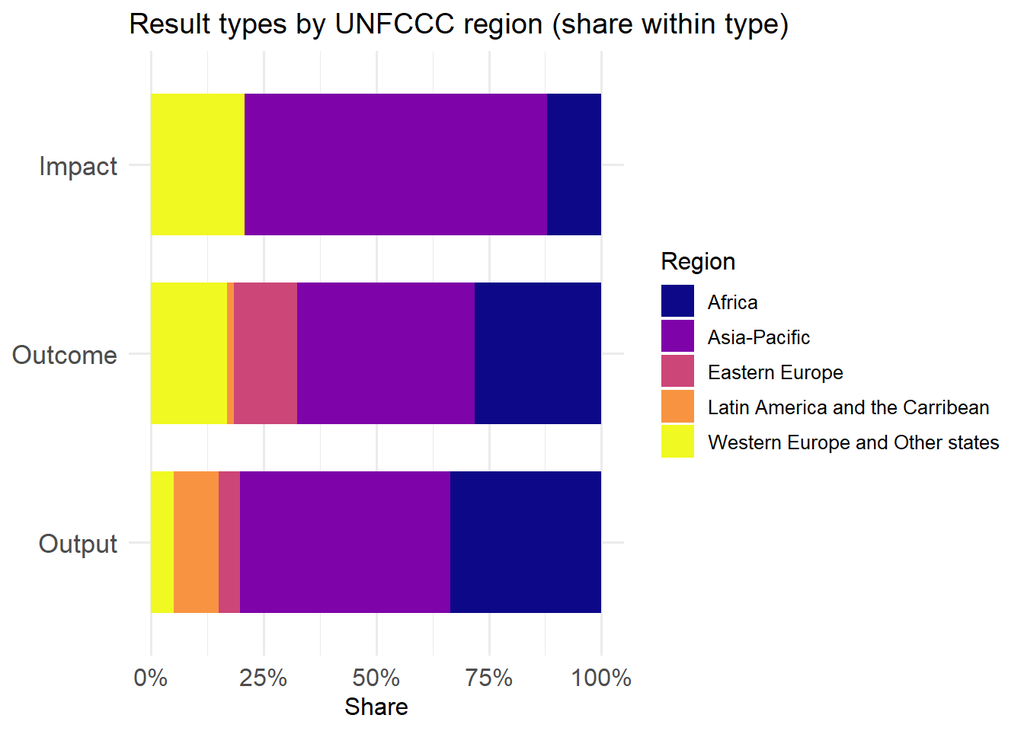

# Step 7 : Adaptation priorities

List of adaptation priorities : - **Water use efficiency & demand management** — Reduce water losses and improve irrigation efficiency/productivity.  
- **Alternative & non-conventional water resources** — Options like rainwater harvesting, greywater reuse, desalination, and storage.  
- **Agribusiness enhancement & private sector development** — Strengthening agribusinesses, value chains, and SME/market linkages.  
- **Legal, policy & institutional frameworks** — Laws, policies, governance, and institutional capacity for adaptation.  
- **Climate-smart agriculture (CSA) & resilient farming systems** — Practices like crop diversification, agroforestry, and soil management.  
- **Sustainable land & farm management** — Sustainable land practices, organic/landscape approaches.  
- **Climate-resilient crops & seeds** — Breeding and access to drought/heat/pest-resistant varieties and seeds.  
- **Farmer capacity, extension & knowledge services** — Training, extension services, and farmer knowledge exchange.  
- **Agricultural water management** — On-farm water efficiency, watershed management, and irrigation.  
- **Rural development & livelihood diversification** — Enhancing rural infrastructure, markets, and income sources.  
- **Ecosystem protection, restoration & protected areas** — Conserving and restoring ecosystems and biodiversity.  
- **Combat land degradation & desertification** — Tackling soil erosion, fertility loss, and desertification.  
- **Afforestation, reforestation & carbon sinks** — Tree planting and forest cover expansion for carbon sequestration.  
- **Invasive species management** — Control and management of invasive alien species.  
- **Land-use & spatial planning integration** — Adaptation in zoning, territorial, and land-use planning.  
- **Monitoring, data & hydrological observation** — Climate monitoring, data systems, and hydrological observation.  
- **National adaptation frameworks & strategies** — National-level plans/frameworks (e.g., NAP, NCCAS).  
- **Local adaptation capacity & community empowerment** — Community-based adaptation and local empowerment.  
- **Public awareness, education & engagement** — Campaigns, curricula, and awareness programs.  
- **Institutional & technical capacity building** — Training, institutional strengthening, inter-agency coordination.  
- **Policy mainstreaming & regulatory integration** — Integrating adaptation into policies and regulations.  
- **Cross-sectoral collaboration & partnerships** — Partnerships and coordination across sectors.  
- **Data management, knowledge & information services** — Knowledge management, sharing, and tools.  
- **Evidence base, risk & impact assessments** — Vulnerability, risk, and impact assessments.  
- **Subnational adaptation priorities & sector packages** — Region- or sector-specific strategies and action packages.  
- **Agro-meteorological & climate information services** — Forecasts, advisories, and information services for agriculture.  
- **Post-harvest, food loss reduction & risk transfer** — Reducing losses, value addition, insurance, and cold chains.  
- **Climate-resilient livestock systems** — Livestock management, resilient breeds, and animal health.  
- **Research, innovation & investment (agri/health)** — Research, technology, and innovation in agriculture and health.  
- **Fire management & response capability** — Fire prevention, management, and emergency response.  
- **Community-based forest management & re/afforestation** — Local forest management and reforestation.  
- **Biodiversity assessment & monitoring** — Biodiversity inventories, monitoring, and assessments.  
- **Public health: surveillance, systems & workforce** — Disease surveillance, early warning, and health workforce.  
- **Public health infrastructure & services** — Facilities, WASH, energy, and resilient health services.  
- **Urban climate resilience & planning** — Climate-proofed urban planning and infrastructure.  
- **Urban green/blue infrastructure & heat mitigation** — Greening, cooling, water-sensitive infrastructure.  
- **Disaster risk reduction, EWS & emergency management** — DRR, early warning systems, and emergency response.  
- **Energy & grid resilience** — Strengthening energy infrastructure and supply chains.  
- **Coastal & marine ecosystem protection/restoration** — Mangroves, reefs, wetlands, and coastal restoration.  
- **Agricultural resource efficiency & high-standard farmland** — Efficient farmland, fertilizer, and input use.  
- **Water allocation, security & quantified targets** — Ensuring water security with defined consumption/coverage targets.  
- **Transport infrastructure & services adaptation** — Climate-proofing roads, ports, rail, and mobility.  
- **Industry & mining adaptation** — Industrial resilience and climate-compatible mining.  
- **Sectoral adaptation plans & guidelines** — Guidelines and action plans for specific sectors (e.g., tourism).  
- **Finance, insurance & social protection** — Climate finance, insurance, and social safety nets.  
- **Tourism sector adaptation** — Adaptation strategies for tourism and ecotourism.  
- **Gender & social inclusion** — Gender-sensitive and socially inclusive adaptation approaches.

by regions

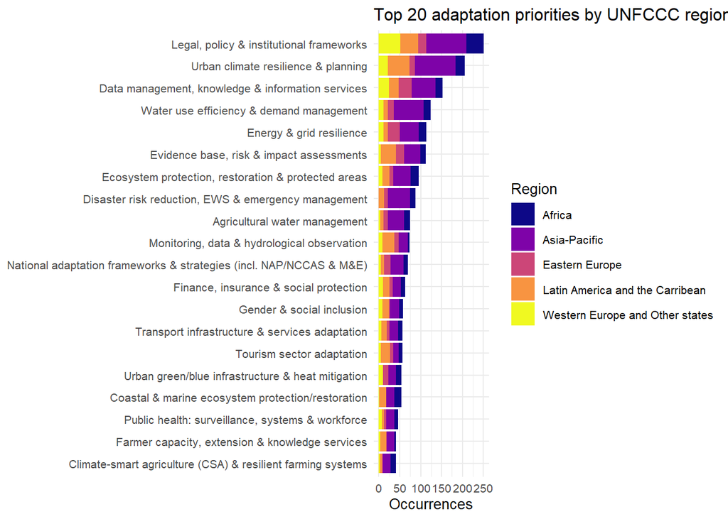

| Priority Category | Asia-Pacific | Latin America and the Carribean | Western Europe and Other states | Africa | Eastern Europe |
| --- | --- | --- | --- | --- | --- |
| Legal, policy &amp; institutional frameworks | 95 | 43 | 51 | 42 | 20 |
| Urban climate resilience &amp; planning | 97 | 52 | 21 | 22 | 13 |
| Data management, knowledge &amp; information services | 57 | 24 | 24 | 16 | 31 |
| Water use efficiency &amp; demand management | 71 | 10 | 11 | 17 | 15 |
| Energy &amp; grid resilience | 45 | 11 | 11 | 19 | 28 |
| Evidence base, risk &amp; impact assessments | 38 | 36 | 5 | 13 | 20 |
| Ecosystem protection, restoration &amp; protected areas | 41 | 16 | 9 | 20 | 10 |
| Disaster risk reduction, EWS &amp; emergency management | 53 | 13 | 0 | 14 | 8 |
| Agricultural water management | 38 | 8 | 3 | 14 | 11 |
| Monitoring, data &amp; hydrological observation | 22 | 29 | 8 | 4 | 10 |

[output cut: 37 more lines]

```r
library(dplyr)
library(stringr)
library(tidyr)
library(ggplot2)
library(DT)


region_key <- overview %>%
  select(Country, Region) %>%
  distinct()

# add manual fixes for missing countries
manual_add <- tibble::tribble(
  ~Country,        ~Region,
  "Moldova",       "Eastern Europe",
  "Phillipines",   "Asia-Pacific",
  "Russia",        "Eastern Europe",
  "Türkiye",       "Asia-Pacific",
  "USA",           "Western Europe and Other states"
)

# combine with existing region_key
region_key <- region_key %>%
  bind_rows(manual_add) %>%
  distinct()


adaptdata_with_region <- adaptdata %>%
  left_join(region_key, by = "Country")

# 1) Counts by Region x Priority
priority_counts_region <- adaptdata_with_region %>%
  filter(tolower(Element) == "adaptation priorities",
         !is.na(PriorityCategories),
         str_detect(PriorityCategories, "\\S")) %>%
  separate_rows(PriorityCategories, sep = ";") %>%
  mutate(
    PriorityCategories = str_squish(PriorityCategories),
    Region = if_else(is.na(Region) | !nzchar(Region), "Unknown", Region)
  ) %>%
  filter(PriorityCategories != "") %>%
  count(Region, PriorityCategories, sort = TRUE) %>%
  rename(`Priority Category` = PriorityCategories,
         Occurrences = n)

# 2) Pick TOP 20 categories by total across regions
top20 <- priority_counts_region %>%
  group_by(`Priority Category`) %>%
  summarise(Total = sum(Occurrences), .groups = "drop") %>%
  slice_max(Total, n = 20, with_ties = FALSE)

priority_counts_region_top20 <- priority_counts_region %>%
  semi_join(top20, by = "Priority Category") %>%
  left_join(top20, by = "Priority Category") %>%
  mutate(`Priority Category` = reorder(`Priority Category`, Total)) %>%
  arrange(Total)

# 3) Stacked plot by Region (top 20 only)
priority_plot_region <- ggplot(priority_counts_region_top20,
  aes(x = `Priority Category`, y = Occurrences, fill = Region)) +
  geom_col(position = "stack") +
  coord_flip() +
  scale_fill_viridis_d(option = "plasma", name = "Region") +
  labs(title = "Top 20 adaptation priorities by UNFCCC region (stacked)",
       x = NULL, y = "Occurrences") +
  theme_minimal(base_size = 10)

priority_plot_region
```

# Step 8 : Adaptation barriers

````r
# ---------------- Setup ----------------
# suppressPackageStartupMessages({
#   library(dplyr); library(stringr); library(glue); library(DT); library(ellmer); library(tidyr)
# })
#
# # Model + batching
# BARRIER_MODEL <- "gpt-5-nano"
# CHUNK_SIZE    <- 30
# MAX_LABELS_PER_PASSAGE <- 3
#
# # ---- API key ----
# btr_key <- Sys.getenv("BTR_KEY")
# stopifnot("BTR_KEY is not set in your environment." = nzchar(btr_key))
# Sys.setenv(OPENAI_API_KEY = btr_key)
#
# # ---------------- Canonical labels ----------------
# BARRIER_LABELS <- c(
#   "Financial",
#   "Economic",
#   "Human capacities",
#   "Informational",
#   "Institutional",
#   "Organizational",
#   "Technological",
#   "Physical",
#   "Social/ cultural",
#   "Biological",
#   "Other emerging issues"
# )
#
# # Map small variants to the exact allowed strings (extra safety)
# canonicalize_barrier_label <- function(x) {
#   if (is.null(x) || is.na(x)) return("Other emerging issues")
#   raw <- tolower(trimws(x))
#   raw <- gsub("[[:punct:]]+$", "", raw)
#   raw <- gsub("\\s+", " ", raw)
#
#   map <- list(
#     "financial"            = c("financial","financing","funding","budget","costs"),
#     "economic"             = c("economic","macro-economic","macroeconomic","market","livelihood"),
#     "human capacities"     = c("human capacity","human capacities","capacity","capacities","skills","staffing"),
#     "informational"        = c("informational","information","knowledge","data gaps","monitoring and data","evidence","m&e","monitoring"),
#     "institutional"        = c("institutional","governance","policy","regulatory","mainstreaming"),
#     "organizational"       = c("organizational","organisational","coordination","mandates","roles and responsibilities","role clarity"),
#     "technological"        = c("technological","technology","tech","innovation","digital"),
#     "physical"             = c("physical","biophysical","infrastructure","geographical","terrain","remoteness"),
#     "social/ cultural"     = c("social/ cultural","social/cultural","sociocultural","social and cultural","social-cultural","social","cultural"),
#     "biological"           = c("biological","bio-physical limits","biophysical limits","climatic limits","ecophysiological"),
#     "other emerging issues"= c("other emerging issues","other","emerging issues","pandemics","covid","invasions","invasion")
#   )
#   for (k in names(map)) if (raw %in% map[[k]]) {
#     return(BARRIER_LABELS[match(tolower(k), tolower(BARRIER_LABELS))])
#   }
#   hit <- BARRIER_LABELS[tolower(BARRIER_LABELS) == raw]
#   if (length(hit)) return(hit)
#   "Other emerging issues"
# }
#
# canonicalize_barrier_vector <- function(v) {
#   v <- v[ nzchar(trimws(v)) ]
#   if (!length(v)) return("Other emerging issues")
#   v <- unique(vapply(v, canonicalize_barrier_label, character(1)))
#   # keep at most MAX_LABELS_PER_PASSAGE
#   v <- v[seq_len(min(length(v), MAX_LABELS_PER_PASSAGE))]
#   paste(v, collapse = "; ")
# }
#
# # ---------------- Multi-label batch prompt ----------------
# make_barrier_batch_prompt <- function(txts) {
#   glue::glue(
# "Task: For each passage, select all applicable *Adaptation barriers* (1–{MAX_LABELS_PER_PASSAGE}) using ONLY the labels below.
# If uncertain, choose the closest categories (do NOT output NA). Return N lines, same order; separate multiple with '; '.
#
# Allowed labels (exact strings):
# - Financial — inadequate/lack of funds or budgets; affordability/cost constraints.
# - Economic — constraints from current livelihoods, market structure, macro-economy, and the development level of key sectors.
# - Human capacities — gaps in skills/training/education and adequate staffing at individual/organizational/societal levels.
# - Informational — gaps in information/awareness/knowledge/data/monitoring needed to guide or assess adaptation; ALSO gaps in data infrastructure and knowledge-management systems (platforms, registries, databases, MIS, M&E systems).
# - Institutional — weaknesses in policies/regulations/plans or inadequate mainstreaming of adaptation into other policies.
# - Organizational — weak organizations/mandates/coordination/designated entities; poor stakeholder inclusion/participation.
# - Technological — limited access to technologies/innovation/equipment, INCLUDING limitations of manmade/built infrastructure.
# - Physical — barriers from the natural physical environment (terrain, remoteness, topography, soils, floodplains, coastlines).
# - Social/ cultural — norms, values, identity, beliefs, place attachment, justice/equity, social support, security issues.
# - Biological — biophysical/climatic/physiological limits (extreme temperature/precipitation/salinity/acidity/extreme-event frequency).
# - Other emerging issues — contextual shocks (e.g., pandemics, invasions).
#
# Disambiguation (key cues):
# - Data/knowledge/M&E platforms/registries/databases → Informational (not Institutional).
# - Coordination/mandates/role clarity/designated entities → Organizational.
# - Manmade/built infrastructure constraints → Technological (Physical is ONLY natural environment).
# - Budget/funding/affordability → Financial; broader livelihoods/markets/macroeconomy → Economic.
#
# Output format: EXACT label strings separated by '; ' (max {MAX_LABELS_PER_PASSAGE}). No extra words.
#
# INPUTS (numbered):
# {paste0(sprintf('%d) %s', seq_along(txts), txts), collapse = '\n')}"
#   )
# }
#
# # ---------------- Batch classifier (multi-label) ----------------
# classify_barrier_type_batch <- function(txts, model = BARRIER_MODEL, chunk_size = CHUNK_SIZE) {
#   if (!length(txts)) return(character(0))
#   chat <- ellmer::chat_openai(model = model)
#   out  <- vector("character", length(txts))
#
#   idx    <- seq_along(txts)
#   chunks <- split(idx, ceiling(idx / chunk_size))
#
#   pb <- txtProgressBar(min = 0, max = length(chunks), style = 3)
#   on.exit(close(pb), add = TRUE)
#
#   for (i in seq_along(chunks)) {
#     ids    <- chunks[[i]]
#     prompt <- make_barrier_batch_prompt(txts[ids])
#
#     ans <- tryCatch(chat$chat(prompt), error = function(e) e)
#     if (inherits(ans, "error")) {
#       warning("GPT batch failed: ", conditionMessage(ans), " — defaulting to 'Other emerging issues' for this chunk.")
#       out[ids] <- "Other emerging issues"
#       setTxtProgressBar(pb, i); next
#     }
#
#     lines <- strsplit(ans, "\\r?\\n", perl = TRUE)[[1]]
#     lines <- trimws(lines)
#     lines <- lines[nzchar(lines)]
#     lines <- sub("^[0-9]+[.)\\-:]\\s*", "", lines, perl = TRUE)
#
#     # align to input size
#     if (length(lines) < length(ids)) lines <- c(lines, rep("Other emerging issues", length(ids) - length(lines)))
#     if (length(lines) > length(ids)) lines <- lines[seq_along(ids)]
#
#     # split by ';', canonicalize each, cap to MAX_LABELS_PER_PASSAGE, then collapse back
#     out[ids] <- vapply(lines, function(s) {
#       labs <- unlist(strsplit(s, "\\s*;\\s*", perl = TRUE))
#       canonicalize_barrier_vector(labs)
#     }, character(1))
#
#     setTxtProgressBar(pb, i)
#   }
#   out
# }
#
# # ---------------- Run on your data ----------------
# if (!"BarrierType_GPT" %in% names(adaptdata)) adaptdata$BarrierType_GPT <- NA_character_
#
# bar_idx <- which(
#   grepl("barrier", adaptdata$Element, ignore.case = TRUE) |
#   grepl("barrier", adaptdata$ElementLabel, ignore.case = TRUE)
# )
#
# if (length(bar_idx)) {
#   cat("Classifying adaptation barriers for", length(bar_idx), "rows (multi-label, batched)...\n")
#   adaptdata$BarrierType_GPT[bar_idx] <-
#     classify_barrier_type_batch(adaptdata$ElementText[bar_idx],
#                                 model = BARRIER_MODEL,
#                                 chunk_size = CHUNK_SIZE)
# } else {
#   cat("No rows with Element/ElementLabel containing 'barrier' found.\n")
# }

#write.csv(adaptdata,"data/adaptdata_barriers.csv")
 # ---------------- Explode to row-per-barrier (to mirror manual duplication) ----------------
# adaptdata_barriers_long <- adaptdata %>%
#   filter(row_number() %in% bar_idx) %>%
#   mutate(BarrierType_GPT = ifelse(is.na(BarrierType_GPT) | !nzchar(BarrierType_GPT),
#                                   "Other emerging issues", BarrierType_GPT)) %>%
#   separate_rows(BarrierType_GPT, sep = "\\s*;\\s*")
#
# # Quick preview
# DT::datatable(
#   adaptdata_barriers_long %>%
#     select(Country, Document, Element, ElementLabel, ElementText, BarrierType_GPT),
#   escape = FALSE,
#   caption = "🚧 Adaptation barriers — GPT (exploded to one row per barrier)",
#   options = list(pageLength = 10, autoWidth = TRUE, dom = "tip")
# )
#
# # Optional: counts
# barrier_counts <- adaptdata_barriers_long %>%
#   count(BarrierType_GPT, sort = TRUE)
# print(barrier_counts)
#
# # Optional save
# # write.csv(adaptdata_barriers_long, "data/adaptdata_barriers_long_nano6.csv", row.names = FALSE)
#
# # ---------------- Helper: agreement vs manual after dedup ----------------
# # Expects a data.frame `a` with columns: Element, ElementText, BarrierType (manual), BarrierType_GPT (semicolon string or exploded)
#
# a<-adaptdata_barriers_long%>%select(Element,ElementText,BarrierType,BarrierType_GPT)
#
# compare_barrier_agreement <- function(a) {
#   # Explode GPT side if needed
#   a_exp <- a %>%
#     mutate(BarrierType_GPT = ifelse(is.na(BarrierType_GPT), "", BarrierType_GPT)) %>%
#     separate_rows(BarrierType_GPT, sep = "\\s*;\\s*")
#
#   # Deduplicate manual rows: one row per (Element, ElementText, BarrierType)
#   a_dedup <- a_exp %>%
#     group_by(Element, ElementText, BarrierType) %>%
#     summarise(BarrierType_GPT = first(BarrierType_GPT), .groups = "drop") %>%
#     mutate(
#       BarrierType_norm    = tolower(trimws(BarrierType)),
#       BarrierType_GPT_norm= tolower(trimws(BarrierType_GPT)),
#       match = BarrierType_norm == BarrierType_GPT_norm
#     )
#
#   agreement <- mean(a_dedup$match, na.rm = TRUE)
#
#   confusion <- a_dedup %>%
#     count(Manual = BarrierType, GPT = BarrierType_GPT) %>%
#     arrange(desc(n))
#
#   list(agreement = agreement, confusion = confusion, n = nrow(a_dedup))
# }
#
# ```
#
# ```{r}
# a_dedup <- a %>%
#   group_by(Element, ElementText, BarrierType) %>%
#   summarise(BarrierType_GPT = first(BarrierType_GPT), .groups = "drop")
#
# # 2. Compare manual vs GPT
# a_dedup <- a_dedup %>%
#   mutate(match = tolower(trimws(BarrierType)) == tolower(trimws(BarrierType_GPT)))
#
# # 3. Agreement rate
# agreement <- mean(a_dedup$match, na.rm = TRUE)
````

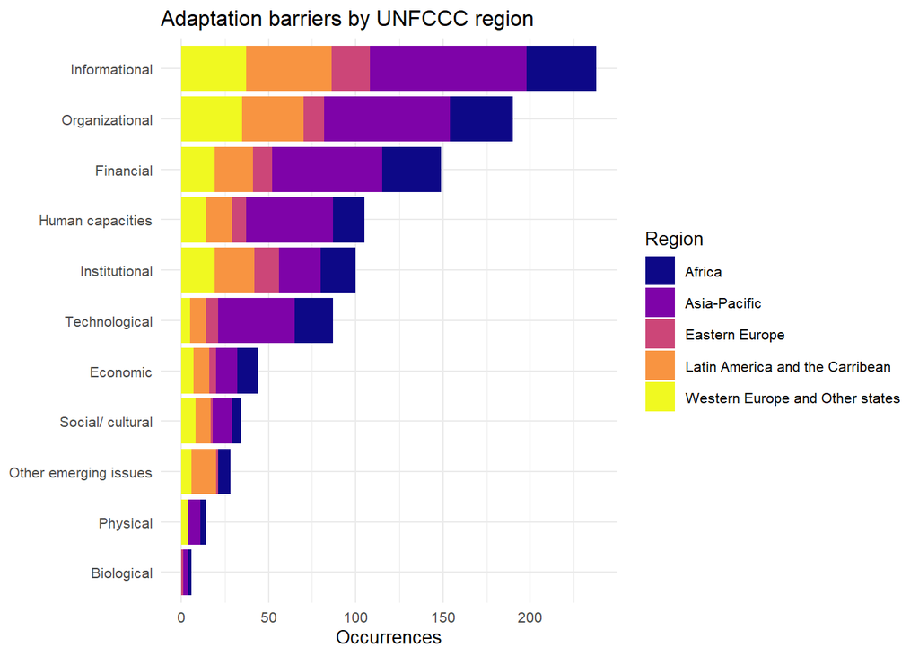

```r
adaptdata<-read.csv("data/adaptdata_barriers.csv")

# a<-adaptdata_barriers_long%>%filter(Element=="Barriers")%>%select(RowID,Country,Element,ElementText,BarrierType,BarrierType_GPT)%>%distinct
# Build region key (+ manual fixes)
region_key <- overview %>%
  dplyr::select(Country, Region) %>%
  dplyr::distinct()

manual_add <- tibble::tribble(
  ~Country,      ~Region,
  "Moldova",     "Eastern Europe",
  "Phillipines", "Asia-Pacific",
  "Russia",      "Eastern Europe",
  "Türkiye",     "Asia-Pacific",
  "USA",         "Western Europe and Other states"
)

region_key <- region_key %>%
  dplyr::bind_rows(manual_add) %>%
  dplyr::distinct()

# Join regions
adaptdata_with_region <- adaptdata %>%
  dplyr::left_join(region_key, by = "Country")

# 1) Counts by Region x Barrier (using BarrierType_GPT; split on ';')
barrier_counts_region <- adaptdata_with_region %>%
  dplyr::filter(stringr::str_to_lower(Element) == "barriers",
                !is.na(BarrierType_GPT),
                stringr::str_detect(BarrierType_GPT, "\\S")) %>%
  tidyr::separate_rows(BarrierType_GPT, sep = "\\s*;\\s*") %>%   # split multi-label cells
  dplyr::mutate(
    BarrierType_GPT = stringr::str_squish(BarrierType_GPT),
    Region = dplyr::if_else(is.na(Region) | !nzchar(Region), "Unknown", Region)
  ) %>%
  dplyr::filter(BarrierType_GPT != "") %>%
  # avoid counting duplicate barrier labels for identical passages
  dplyr::distinct(Country, Document, Element, ElementLabel, ElementText, Region, BarrierType_GPT) %>%
  dplyr::count(Region, BarrierType_GPT, sort = TRUE) %>%
  dplyr::rename(`Barrier Type` = BarrierType_GPT,
                Occurrences = n)

# 2) Pick TOP 20 categories by total across regions
top20 <- barrier_counts_region %>%
  dplyr::group_by(`Barrier Type`) %>%
  dplyr::summarise(Total = sum(Occurrences), .groups = "drop") %>%
  dplyr::slice_max(Total, n = 20, with_ties = FALSE)

barrier_counts_region_top20 <- barrier_counts_region %>%
  dplyr::semi_join(top20, by = "Barrier Type") %>%
  dplyr::left_join(top20, by = "Barrier Type") %>%
  dplyr::mutate(`Barrier Type` = reorder(`Barrier Type`, Total)) %>%
  dplyr::arrange(Total)

# 3) Stacked plot by Region (top 20 only)
barrier_plot_region <- ggplot2::ggplot(barrier_counts_region_top20,
  ggplot2::aes(x = `Barrier Type`, y = Occurrences, fill = Region)) +
  ggplot2::geom_col(position = "stack") +
  ggplot2::coord_flip() +
  ggplot2::scale_fill_viridis_d(option = "plasma", name = "Region") +
  ggplot2::labs(title = "Adaptation barriers by UNFCCC region",
       x = NULL, y = "Occurrences") +
  ggplot2::theme_minimal(base_size = 10)

barrier_plot_region
```

#Step 9 : Summary table for Sankey plot

```r
# Load the new dataset
# adaptdata_new <- read.csv("adaptdata_action_level_nano6.csv")
#
# # Make sure both have RowID
# if(!"RowID" %in% names(adaptdata_new)) stop("RowID missing in new data")
# if(!"...1" %in% names(adaptdata)) stop("RowID missing in current adaptdata")
#
# # Keep only the mapping from old data
# gga_map <- adaptdata %>%
#   rename(RowID="...1")%>%
#   select(RowID, SectorType_GGA)
#
# # Replace SectorType_GGA in the new dataset
# adaptdata <- adaptdata_new %>%
#   select(-SectorType_GGA) %>%        # drop old col
#   left_join(gga_map, by = "RowID")   # bring in correct values
#
#
# # Optionally save
# # write.csv(adaptdata_merged, "adaptdata_with_correct_GGA.csv", row.names = FALSE)
#
#
# # ----------------------------
# # 1) Pick your source data
# # ----------------------------
# # Replace `df` with your actual data frame (e.g., df <- check or df <- adaptdata)
# df <- adaptdata   # or: df <- adaptdata
#
# # ----------------------------
# # 2) Normalize key columns
# #    GGA theme, Action level, Action type
# # ----------------------------
# actions <- df %>%
#   filter(tolower(Element) == "action") %>%
#   mutate(
#     GGA          = str_squish(SectorType_GGA),
#     ActionLevel  = str_squish(coalesce(ActionLevel_GPT, Action.level)),
#     # Choose which "type" you want to show in the Sankey’s last column:
#     #   - ActionType_GPT (your action-type buckets), or
#     #   - InterventionType_GPT (your intervention-type buckets)
#     ActionType   = str_squish(coalesce(ActionType_GPT, InterventionType_GPT))
#   ) %>%
#   # keep only rows that have at least GGA and ActionLevel
#   filter(!is.na(GGA), GGA != "",
#          !is.na(ActionLevel), ActionLevel != "")
#
# # split multiple ActionTypes (e.g., "economic; institutional")
# actions_long <- actions %>%
#   separate_rows(ActionType, sep = ";|,") %>%
#   mutate(ActionType = str_squish(ActionType)) %>%
#   filter(!is.na(ActionType), ActionType != "")
#
# # ----------------------------
# # 3) Count linkages for the Sankey
# # ----------------------------
# # (a) GGA -> ActionLevel
# edges_gga_level <- actions %>%
#   count(source = GGA, target = ActionLevel, name = "value", sort = TRUE) %>%
#   mutate(stage = "GGA→ActionLevel")
#
# # (b) ActionLevel -> ActionType
# edges_level_type <- actions_long %>%
#   count(source = ActionLevel, target = ActionType, name = "value", sort = TRUE) %>%
#   mutate(stage = "ActionLevel→ActionType")
#
# # Combine into one edge list
# sankey_edges <- bind_rows(edges_gga_level, edges_level_type)
#
# # ----------------------------
# # 4) (Optional) Triple counts
# #     GGA x ActionLevel x ActionType — useful for QA or other visuals
# # ----------------------------
# triples <- actions_long %>%
#   count(GGA, ActionLevel, ActionType, name = "value", sort = TRUE)
#
# # ----------------------------
# # 5) (Optional) Nodes table (for tools that want nodes + edges)
# # ----------------------------
# nodes <- sankey_edges %>%
#   select(source) %>% rename(node = source) %>%
#   bind_rows(sankey_edges %>% select(target) %>% rename(node = target)) %>%
#   distinct() %>%
#   arrange(node) %>%
#   mutate(id = row_number() - 1L)  # 0-based IDs
#
# # ----------------------------
# # 6) Export for Sankey tools / SankeyMATIC
# # ----------------------------
# write_csv(sankey_edges, "sankey_edges_gga_level_type.csv")
# write_csv(triples,     "sankey_triples_gga_level_type.csv")
```

# Step 10 : analyze linkages at the impact and action level

**Method overview**

**Goal.** Check how well countries’ actions/results target the same GGA themes where risks/impacts are most prominent—and visualize any gaps.

**Inputs** - **Core fields:** `Country`, `Element` (*System at risk*, *Climate impact*, *Action*, *Result*), `SectorType_GGA` (GGA theme). - **Optional:** `ResultType_GPT` (*Output* / *Outcome* / *Impact*) for weighting **Result** rows.

**Cleaning & mapping** - **Clean:** trim text, standardize blanks, drop placeholder “NA” themes. - **Map to two sides:** - **Risk/Impact:** `Element ∈ {System at risk, Climate impact}` - **Action/Result:** `Element ∈ {Action, Result}` - **Themes:** fix a consistent theme order; include only themes present in the data.

**Counting → shares** For each **country × theme**: 1. **Risk count:** `Risk_Count` = rows on the **Risk/Impact** side.  
2. **Action count:** `Action_Count` = rows on the **Action/Result** side  
*(optionally weight Result rows by `ResultType_GPT`; Actions = 1).* 3. **Shares (within-side):**  
`Risk_Share = Risk_Count / Σ Risk_Count`  
`Action_Share = Action_Count / Σ Action_Count`

**Theme gap (delta)** `Delta = Action_Share − Risk_Share` per theme.  
**Positive** = actions over-represented vs risk; **negative** = under-represented.

**Coherence score (0–1)** Compare the two share vectors (Risk vs Action) using: - **Cosine similarity** (pattern overlap), and - **Jensen–Shannon similarity** (distributional closeness).

**Final score** = average of the two, clipped to **[0, 1]**.  
Higher = better alignment between where risks appear and where actions focus.

**Figures** - **Country paired bars:** Risk vs Action **shares** by theme (within a country). - **Stacked bars (counts):** Absolute composition by theme for each side (**no forced 100%**). - **Coherence summary:** One bar per country (higher = more aligned). - **Delta heatmap:** `Action_Share − Risk_Share` by country × theme  
*(red = over-actioned; blue = under-actioned).*

**Interpretation** - A theme appears in the **Risk share** if tagged under **System at risk** or **Climate impact**. - A theme appears in the **Action share** if tagged under **Action** or **Result**. - **Alignment**: largest risk themes ≈ largest action themes; **misalignment** highlights priority gaps.

|  | Country | Risk_rows | Action_rows | Coherence_Score(0-1) | Cosine_Sim | JS_Sim | Top_UnderAddressed | Top_OverIndexed |
| --- | --- | --- | --- | --- | --- | --- | --- | --- |
| 1 | South Africa | 110 | 163 | 0.914 | 0.969 | 0.859 | Food and agriculture (-0.06); Infrastructure and human settlements (-0.04); Water and sanitation (-0.03) | Health (+0.07); Biodiversity and ecosystems (+0.04); Poverty eradication and livelihoods (+0.02) |
| 2 | Egypt | 42 | 15 | 0.912 | 0.957 | 0.867 | Biodiversity and ecosystems (-0.06); Poverty eradication and livelihoods (-0.05); Water and sanitation (-0.03) | Infrastructure and human settlements (+0.08); Health (+0.04); Food and agriculture (+0.03) |
| 3 | Maldives | 70 | 16 | 0.891 | 0.943 | 0.839 | Biodiversity and ecosystems (-0.09); Water and sanitation (-0.07); Cultural heritage (+0.00) | Poverty eradication and livelihoods (+0.09); Infrastructure and human settlements (+0.04); Food and agriculture (+0.02) |
| 4 | Seychelles | 107 | 50 | 0.875 | 0.965 | 0.785 | Biodiversity and ecosystems (-0.13); Food and agriculture (-0.03); Poverty eradication and livelihoods (-0.03) | Water and sanitation (+0.09); Health (+0.05); Infrastructure and human settlements (+0.05) |
| 5 | Denmark | 67 | 55 | 0.866 | 0.937 | 0.796 | Infrastructure and human settlements (-0.11); Food and agriculture (-0.05); Health (-0.03) | Water and sanitation (+0.10); Poverty eradication and livelihoods (+0.05); Biodiversity and ecosystems (+0.04) |
| 6 | Bulgaria | 107 | 21 | 0.844 | 0.916 | 0.772 | Water and sanitation (-0.13); Health (-0.04); Poverty eradication and livelihoods (-0.04) | Food and agriculture (+0.11); Biodiversity and ecosystems (+0.09); Infrastructure and human settlements (+0.00) |
| 7 | Gabon | 15 | 2 | 0.831 | 0.99 | 0.671 | Water and sanitation (-0.07); Food and agriculture (-0.07); Infrastructure and human settlements (-0.07) | Biodiversity and ecosystems (+0.20); Health (+0.00); Poverty eradication and livelihoods (+0.00) |
| 8 | Kenya | 63 | 140 | 0.825 | 0.908 | 0.743 | Food and agriculture (-0.09); Health (-0.08); Water and sanitation (-0.07) | Infrastructure and human settlements (+0.13); Biodiversity and ecosystems (+0.05); Poverty eradication and livelihoods (+0.04) |
| 9 | Moldova | 21 | 22 | 0.824 | 0.919 | 0.728 | Food and agriculture (-0.20); Biodiversity and ecosystems (-0.05); Poverty eradication and livelihoods (+0.00) | Water and sanitation (+0.11); Infrastructure and human settlements (+0.09); Health (+0.04) |
| 10 | Nepal | 37 | 79 | 0.818 | 0.899 | 0.736 | Poverty eradication and livelihoods (-0.14); Food and agriculture (-0.07); Cultural heritage (+0.00) | Water and sanitation (+0.14); Biodiversity and ecosystems (+0.04); Health (+0.01) |

[output cut: 85 more lines]

|  | SectorType_GGA | Risk_Count | Action_Count | Risk_Share | Action_Share | Delta_Share_Action_minus_Risk | Country |
| --- | --- | --- | --- | --- | --- | --- | --- |
| 1 | Water and sanitation | 26 | 12 | 0.565 | 0.3 | -0.265 | Algeria |
| 2 | Food and agriculture | 8 | 12 | 0.174 | 0.3 | 0.126 | Algeria |
| 3 | Health | 4 | 0 | 0.087 | 0 | -0.087 | Algeria |
| 4 | Biodiversity and ecosystems | 8 | 16 | 0.174 | 0.4 | 0.226 | Algeria |
| 5 | Infrastructure and human settlements | 0 | 0 | 0 | 0 | 0 | Algeria |
| 6 | Poverty eradication and livelihoods | 0 | 0 | 0 | 0 | 0 | Algeria |
| 7 | Cultural heritage | 0 | 0 | 0 | 0 | 0 | Algeria |
| 8 | Water and sanitation | 17 | 0 | 0.156 | 0 | -0.156 | Andorra |
| 9 | Food and agriculture | 17 | 1 | 0.156 | 0.25 | 0.094 | Andorra |
| 10 | Health | 8 | 0 | 0.073 | 0 | -0.073 | Andorra |

[output cut: 655 more lines]

|  | Country | Risk_rows | Action_rows | Coherence_Score(0-1) | Cosine_Sim | JS_Sim | Top_UnderAddressed | Top_OverIndexed |
| --- | --- | --- | --- | --- | --- | --- | --- | --- |
| 1 | South Africa | 110 | 163 | 0.914 | 0.969 | 0.859 | Food and agriculture (-0.06); Infrastructure and human settlements (-0.04); Water and sanitation (-0.03) | Health (+0.07); Biodiversity and ecosystems (+0.04); Poverty eradication and livelihoods (+0.02) |
| 2 | Egypt | 42 | 15 | 0.912 | 0.957 | 0.867 | Biodiversity and ecosystems (-0.06); Poverty eradication and livelihoods (-0.05); Water and sanitation (-0.03) | Infrastructure and human settlements (+0.08); Health (+0.04); Food and agriculture (+0.03) |
| 3 | Maldives | 70 | 16 | 0.891 | 0.943 | 0.839 | Biodiversity and ecosystems (-0.09); Water and sanitation (-0.07); Cultural heritage (+0.00) | Poverty eradication and livelihoods (+0.09); Infrastructure and human settlements (+0.04); Food and agriculture (+0.02) |
| 4 | Seychelles | 107 | 50 | 0.875 | 0.965 | 0.785 | Biodiversity and ecosystems (-0.13); Food and agriculture (-0.03); Poverty eradication and livelihoods (-0.03) | Water and sanitation (+0.09); Health (+0.05); Infrastructure and human settlements (+0.05) |
| 5 | Denmark | 67 | 55 | 0.866 | 0.937 | 0.796 | Infrastructure and human settlements (-0.11); Food and agriculture (-0.05); Health (-0.03) | Water and sanitation (+0.10); Poverty eradication and livelihoods (+0.05); Biodiversity and ecosystems (+0.04) |
| 6 | Bulgaria | 107 | 21 | 0.844 | 0.916 | 0.772 | Water and sanitation (-0.13); Health (-0.04); Poverty eradication and livelihoods (-0.04) | Food and agriculture (+0.11); Biodiversity and ecosystems (+0.09); Infrastructure and human settlements (+0.00) |
| 7 | Gabon | 15 | 2 | 0.831 | 0.99 | 0.671 | Water and sanitation (-0.07); Food and agriculture (-0.07); Infrastructure and human settlements (-0.07) | Biodiversity and ecosystems (+0.20); Health (+0.00); Poverty eradication and livelihoods (+0.00) |
| 8 | Kenya | 63 | 140 | 0.825 | 0.908 | 0.743 | Food and agriculture (-0.09); Health (-0.08); Water and sanitation (-0.07) | Infrastructure and human settlements (+0.13); Biodiversity and ecosystems (+0.05); Poverty eradication and livelihoods (+0.04) |
| 9 | Moldova | 21 | 22 | 0.824 | 0.919 | 0.728 | Food and agriculture (-0.20); Biodiversity and ecosystems (-0.05); Poverty eradication and livelihoods (+0.00) | Water and sanitation (+0.11); Infrastructure and human settlements (+0.09); Health (+0.04) |
| 10 | Nepal | 37 | 79 | 0.818 | 0.899 | 0.736 | Poverty eradication and livelihoods (-0.14); Food and agriculture (-0.07); Cultural heritage (+0.00) | Water and sanitation (+0.14); Biodiversity and ecosystems (+0.04); Health (+0.01) |

[output cut: 10 more lines]

[figure not shown]

```
##
## Saved coherence outputs to:
## outputs/coherence/coherence_summary_ALL.csv
## outputs/coherence/gga_risk_vs_action_tables_ALL.csv
## outputs/coherence/figs/coherence_summary_top20.png
## outputs/coherence/figs/country_stacked_bars_counts_top10_twoBars.png
## outputs/coherence/figs/delta_heatmap_top20.png
```

```
## outputs/coherence/figs/South_Africa_gga_balance_top20.png
## outputs/coherence/figs/Egypt_gga_balance_top20.png
## outputs/coherence/figs/Maldives_gga_balance_top20.png
## outputs/coherence/figs/Seychelles_gga_balance_top20.png
## outputs/coherence/figs/Denmark_gga_balance_top20.png
## outputs/coherence/figs/Bulgaria_gga_balance_top20.png
## outputs/coherence/figs/Gabon_gga_balance_top20.png
## outputs/coherence/figs/Kenya_gga_balance_top20.png
## outputs/coherence/figs/Moldova_gga_balance_top20.png
## outputs/coherence/figs/Nepal_gga_balance_top20.png
## outputs/coherence/figs/Latvia_gga_balance_top20.png
## outputs/coherence/figs/New_Zealand_gga_balance_top20.png
## outputs/coherence/figs/Canada_gga_balance_top20.png
## outputs/coherence/figs/Estonia_gga_balance_top20.png
## outputs/coherence/figs/Azerbaijan_gga_balance_top20.png
## outputs/coherence/figs/Lebanon_gga_balance_top20.png
## outputs/coherence/figs/Portugal_gga_balance_top20.png
## outputs/coherence/figs/Chile_gga_balance_top20.png
## outputs/coherence/figs/France_gga_balance_top20.png
## outputs/coherence/figs/Indonesia_gga_balance_top20.png
```

### Glossary — Global theme ranking (Δ = Action share − Risk share)

- **Rank** — Order by **mean Δ** (highest = most over-represented).
- **Theme (GGA)** — GGA theme name.
- **Direction** — Over / Under / Near-balanced (by sign of mean Δ).
- **Mean Δ (Action−Risk)** — Average across countries of *(Action share − Risk share)* for the theme.
- **Median Δ** — Median of Δ across countries (robust to outliers).
- **Avg Risk share** — Country-average **Risk/Impact** share for the theme  
  *(per-country, Risk shares sum to 1)*.
- **Avg Action share** — Country-average **Action/Result** share for the theme  
  *(per-country, Action shares sum to 1)*.
- **# Over (≥ +5pp)** — Count of countries with Δ ≥ 0.05.
- **# Under (≤ −5pp)** — Count of countries with Δ ≤ −0.05.
- **# Near** — Count with −0.05 < Δ < +0.05.
- **Share Over / Share Under** — Fractions of countries in over/under buckets.
- **Countries counted** — Number of country × theme observations included.

```
##
## === GLOBAL THEME RANKING (Action − Risk) ===
## Averaging across countries: EQUAL-COUNTRY
## Threshold for over/under counts: ±5 pp
## Saved table: outputs/coherence/insights_global/global_theme_ranking_ActionMinusRisk.csv
```

| Rank | Theme (GGA) | Direction | Mean Δ (Action−Risk) | Median Δ | Avg Risk share | Avg Action share | # Over (≥+5pp) | # Under (≤−5pp) | # Near | Share Over | Share Under | Countries counted |
| --- | --- | --- | --- | --- | --- | --- | --- | --- | --- | --- | --- | --- |
| 1 | Infrastructure and human settlements | Over-represented by actions | 0.02 | 0 | 13.8% | 15.7% | 32 | 39 | 24 | 33.7% | 41.1% | 95 |
| 2 | Cultural heritage | Over-represented by actions | 0.003 | 0 | 0.2% | 0.4% | 3 | 0 | 92 | 3.2% | 0.0% | 95 |
| 3 | Poverty eradication and livelihoods | Under-represented by actions | -0.018 | 0 | 6.2% | 4.4% | 18 | 25 | 52 | 18.9% | 26.3% | 95 |
| 4 | Health | Under-represented by actions | -0.04 | -0.035 | 7.5% | 3.5% | 13 | 41 | 41 | 13.7% | 43.2% | 95 |
| 5 | Food and agriculture | Under-represented by actions | -0.042 | -0.052 | 17.4% | 13.2% | 24 | 48 | 23 | 25.3% | 50.5% | 95 |
| 6 | Water and sanitation | Under-represented by actions | -0.06 | -0.066 | 17.2% | 11.2% | 23 | 52 | 20 | 24.2% | 54.7% | 95 |
| 7 | Biodiversity and ecosystems | Under-represented by actions | -0.104 | -0.118 | 32.6% | 22.2% | 24 | 60 | 11 | 25.3% | 63.2% | 95 |

```r
# =========================
# Step 10b (GLOBAL): Which themes are most under/over-represented?
# =========================
# Goal: Aggregate ACROSS COUNTRIES to find the globally under/over-represented themes.
# Uses coh_all$combined from Step 10 (one row per country × theme with shares & delta).
# Falls back to the CSVs saved in Step 10 if 'coh_all' isn't in memory.

suppressPackageStartupMessages({
  library(dplyr); library(tidyr); library(readr); library(DT)
})

# -------- Inputs & paths --------
ins_dir <- file.path(out_dir, "insights_global")
dir.create(ins_dir, recursive = TRUE, showWarnings = FALSE)

combined_tbl <- tryCatch(
  {
    stopifnot(exists("coh_all"))
    coh_all$combined %>% filter(!is.na(SectorType_GGA))
  },
  error = function(e) {
    readr::read_csv(
      file.path(out_dir, "gga_risk_vs_action_tables_ALL.csv"),
      show_col_types = FALSE
    ) %>% filter(!is.na(SectorType_GGA))
  }
)

# -------- Parameters --------
# Threshold for counting "over/under" occurrences (in share points)
THR_GAP <- 0.05  # = 5 percentage points of within-country share

# Optional: equal-weight countries (default) vs. weight by counts.
# If you prefer record-weighted averaging across countries, set WEIGHTED = TRUE
WEIGHTED <- FALSE

# -------- Prep: per-country theme rows --------
# Ensure we have exactly one row per Country × Theme with shares and delta
per_cty_theme <- combined_tbl %>%
  select(
    Country, SectorType_GGA,
    Risk_Share, Action_Share,
    Delta_Share_Action_minus_Risk,
    Risk_Count, Action_Count
  ) %>%
  distinct()

# -------- GLOBAL aggregation across countries --------
if (!WEIGHTED) {
  # Equal-country averaging (default)
  theme_global <- per_cty_theme %>%
    group_by(SectorType_GGA) %>%
    summarise(
      mean_delta   = mean(Delta_Share_Action_minus_Risk, na.rm = TRUE),
      median_delta = median(Delta_Share_Action_minus_Risk, na.rm = TRUE),
      mean_risk    = mean(Risk_Share,   na.rm = TRUE),
      mean_action  = mean(Action_Share, na.rm = TRUE),
      over_n       = sum(Delta_Share_Action_minus_Risk >=  THR_GAP, na.rm = TRUE),
      under_n      = sum(Delta_Share_Action_minus_Risk <= -THR_GAP, na.rm = TRUE),
      countries_n  = n(),
      .groups = "drop"
    ) %>%
    mutate(
      near_n      = countries_n - over_n - under_n,
      rank_over   = rank(-mean_delta, ties.method = "min"),
      rank_under  = rank( mean_delta, ties.method = "min")
    ) %>%
    arrange(desc(mean_delta))
} else {
  # Record-weighted averaging across countries
  theme_global <- per_cty_theme %>%
    mutate(weight = pmax(Risk_Count + Action_Count, 1)) %>%
    group_by(SectorType_GGA) %>%
    summarise(
      mean_delta   = weighted.mean(Delta_Share_Action_minus_Risk, w = weight, na.rm = TRUE),
      median_delta = median(Delta_Share_Action_minus_Risk, na.rm = TRUE),
      mean_risk    = weighted.mean(Risk_Share,   w = weight, na.rm = TRUE),
      mean_action  = weighted.mean(Action_Share, w = weight, na.rm = TRUE),
      over_n       = sum(Delta_Share_Action_minus_Risk >=  THR_GAP, na.rm = TRUE),
      under_n      = sum(Delta_Share_Action_minus_Risk <= -THR_GAP, na.rm = TRUE),
      countries_n  = n(),
      .groups = "drop"
    ) %>%
    mutate(
      near_n      = countries_n - over_n - under_n,
      rank_over   = rank(-mean_delta, ties.method = "min"),
      rank_under  = rank( mean_delta, ties.method = "min")
    ) %>%
    arrange(desc(mean_delta))
}

# -------- Key outputs for the report --------
# 1) Global ranking: most over- vs under-represented themes (by average Δ)
most_over  <- theme_global %>% arrange(desc(mean_delta)) %>% slice_head(n = 3)
most_under <- theme_global %>% arrange(mean_delta)        %>% slice_head(n = 3)

# 2) Clean, rounded overview table
theme_global_out <- theme_global %>%
  mutate(
    across(c(mean_delta, median_delta, mean_risk, mean_action), ~round(., 3))
  ) %>%
  arrange(desc(mean_delta))

# -------- Save & display --------
readr::write_csv(theme_global_out, file.path(ins_dir, "theme_global_overview.csv"))
readr::write_csv(most_over,        file.path(ins_dir, "themes_most_overrepresented.csv"))
readr::write_csv(most_under,       file.path(ins_dir, "themes_most_underrepresented.csv"))

cat("\n=== GLOBAL THEME BALANCE (Action − Risk) ===\n",
    "Averaging across countries (", ifelse(WEIGHTED, "RECORD-WEIGHTED", "EQUAL-COUNTRY"), "):\n",
    "Top over-represented themes (by mean Δ):\n", sep = "")
```

```
##
## === GLOBAL THEME BALANCE (Action − Risk) ===
## Averaging across countries (EQUAL-COUNTRY):
## Top over-represented themes (by mean Δ):
```

```r
print(most_over %>% select(SectorType_GGA, mean_delta, median_delta, over_n, under_n, countries_n))
```

```
## # A tibble: 3 × 6
##   SectorType_GGA              mean_delta median_delta over_n under_n countries_n
##   <chr>                            <dbl>        <dbl>  <int>   <int>       <int>
## 1 Infrastructure and human s…    0.0195             0     32      39          95
## 2 Cultural heritage              0.00269            0      3       0          95
## 3 Poverty eradication and li…   -0.0182             0     18      25          95
```

```r
cat("\nTop under-represented themes (by mean Δ):\n")
```

```
##
## Top under-represented themes (by mean Δ):
```

```r
print(most_under %>% select(SectorType_GGA, mean_delta, median_delta, over_n, under_n, countries_n))
```

```
## # A tibble: 3 × 6
##   SectorType_GGA              mean_delta median_delta over_n under_n countries_n
##   <chr>                            <dbl>        <dbl>  <int>   <int>       <int>
## 1 Biodiversity and ecosystems    -0.104       -0.118      24      60          95
## 2 Water and sanitation           -0.0600      -0.0661     23      52          95
## 3 Food and agriculture           -0.0419      -0.0518     24      48          95
```

```r
cat("\nFull table written to: ", file.path(ins_dir, "theme_global_overview.csv"), "\n", sep = "")
```

```
##
## Full table written to: outputs/coherence/insights_global/theme_global_overview.csv
```

```r
DT::datatable(
  theme_global_out,
  options = list(pageLength = 10, dom = "tip"),
  caption = htmltools::HTML(
    paste0("🌍 <b>Global theme balance</b> — Δ = Action share − Risk share (THR = ",
           THR_GAP * 100, " pp; averaging = ",
           ifelse(WEIGHTED, "record-weighted", "equal-country"), ")")
  )
)
```

|  | SectorType_GGA | mean_delta | median_delta | mean_risk | mean_action | over_n | under_n | countries_n | near_n | rank_over | rank_under |
| --- | --- | --- | --- | --- | --- | --- | --- | --- | --- | --- | --- |
| 1 | Infrastructure and human settlements | 0.02 | 0 | 0.138 | 0.157 | 32 | 39 | 95 | 24 | 1 | 7 |
| 2 | Cultural heritage | 0.003 | 0 | 0.002 | 0.004 | 3 | 0 | 95 | 92 | 2 | 6 |
| 3 | Poverty eradication and livelihoods | -0.018 | 0 | 0.062 | 0.044 | 18 | 25 | 95 | 52 | 3 | 5 |
| 4 | Health | -0.04 | -0.035 | 0.075 | 0.035 | 13 | 41 | 95 | 41 | 4 | 4 |
| 5 | Food and agriculture | -0.042 | -0.052 | 0.174 | 0.132 | 24 | 48 | 95 | 23 | 5 | 3 |
| 6 | Water and sanitation | -0.06 | -0.066 | 0.172 | 0.112 | 23 | 52 | 95 | 20 | 6 | 2 |
| 7 | Biodiversity and ecosystems | -0.104 | -0.118 | 0.326 | 0.222 | 24 | 60 | 95 | 11 | 7 | 1 |

# Save data to a local file

# System at risk → IPCC sector → GGA

# Remarks

- **Hazard Type:**  
  A few additional climate-related keywords were added to improve coverage. For example, terms like *“dry days”*, *“surface air temperature”*, and *“heat stress”* appeared frequently and were added under appropriate hazard categories.  
  However, we also encountered terms such as *“runoff”*, *“solar radiation”*, and *“winds”* that were not clearly assignable to a single hazard category and remain unclassified for now.
- **System at Risk:**  
  We expanded the keyword list to better capture common themes in the data:
  - **Coastal:** Added terms like *“eutrophication”* and *“algal bloom”*, which frequently occur in the context of coastal or marine environmental issues.
  - **Livelihoods and Poverty:** Included tourism-related terms such as *“tourism”*, *“tourists”*, *“ski”*, *“vacation”*, and *“outdoor activities”*, to capture socio-economic impacts on income and livelihoods.
  - **Infrastructure and Services:** Extended to include infrastructure and utility-related keywords such as *“power”*, *“hydropower”*, *“railways”*, *“port”*, *“industry”*, *“industries”*, and *“material”*.
  - **Health:** Added terms like *“pollution”*, *“deaths”*, *“human lives”*, and *“life expectancy”* to better reflect public health consequences mentioned in the data.

  ⚠️ **Note:** We observed several rows tagged as *System at risk* that likely describe hazards rather than systems, as they do not mention any system but describe a climate hazard (e.g., drought or storms). This may warrant a second look or reclassification. Some examples
  - Climate change is projected to cause longer and dryer dry seasons and shorter rainy seasons
  - Increased frequency and intensity of flooding in vulnerable areas
  - Another precursor to higher drought incidence will be the expected change in rainfall variability, with the number of rainfall days decreasing, especially in spring and summer, while the intensity of individual rainfall events increases.
  - Seychelles is projected to experience increased average temperatures and changes in rainfall patterns, leading to more frequent and intense rainfall events, including flooding and landslides, and potentially longer periods of drought
- **Sector Tagging (IPCC & GGA):**  
  Sector tagging shows **strong overall coverage**, particularly due to the mapping from both direct sector mentions and `SystemType`.  
  That said, a number of rows still remain **unclassified**, either because sector information wasn’t mentioned explicitly in the original source or because it was too ambiguous to map reliably. It’s unclear whether these untagged rows should be a concern, but they could be flagged for manual review depending on use case.